# Insurance Fraud

Frank Lauder

2025-03-30

# Introduction

Insurance fraud poses a concern across various sectors, including healthcare, homeownership, and automobile coverage. Its impact extends beyond the financial burden on insurers, affecting even non-fraudulent policyholders.

This analysis zeroes in on fraud within the auto insurance industry in India. The dataset utilized for this project was sourced from Kaggle (https://www.kaggle.com/).

Our objective is to leverage classification models to predict fraudulent auto insurance claims. Various classification models will be evaluated based on their efficacy in accurately predicting instances of actual fraud.

Individuals may not have an interest in every section of this analysis. Specific sections of interest can be directly accessed through the table of contents on the left. For instance, clicking on “Models” will swiftly take one to the classification models section.

The following programs were used for this project.

Python 3.10.10  
R 4.2.2 (Specific Visualizations)

# Packages

```python
import pandas as pd

import pickle

from pandas.api.types import is_numeric_dtype
from pandas.api.types import is_categorical_dtype

import datetime

from datetime import date

from dateutil.relativedelta import relativedelta

import numpy as np

import matplotlib.pyplot as plt

import seaborn as sns

import plotly.express as px

import plotly.io as pio

import matplotlib.patches as mpatches

from plotnine import *

import plotnine

import scipy
from scipy import stats


from sklearn.model_selection import train_test_split


from sklearn.preprocessing import StandardScaler, OrdinalEncoder, LabelEncoder


from sklearn.compose import ColumnTransformer, make_column_transformer

from sklearn.pipeline import Pipeline, make_pipeline

from sklearn.model_selection import StratifiedKFold

from sklearn.model_selection import GridSearchCV, RandomizedSearchCV

from sklearn.compose import make_column_selector as selector

from sklearn.preprocessing import OneHotEncoder


from sklearn import set_config

from sklearn.metrics import confusion_matrix, classification_report, ConfusionMatrixDisplay, accuracy_score, roc_auc_score, recall_score, RocCurveDisplay, precision_score, f1_score, make_scorer

from sklearn import metrics

from sklearn.inspection import permutation_importance

from sklearn.model_selection import cross_val_score,StratifiedKFold


import time

from io import StringIO
from pyod.models.iforest import IForest
from pyod.models.knn import KNN
from pyod.models.lof import LOF
from mlxtend.frequent_patterns import apriori
from sklearn.ensemble import IsolationForest
from sklearn.tree import DecisionTreeClassifier
```

# Exploratory Data Analysis

## Initial Data Analysis

The data was downloaded as five individual data sets. We will review each data set for suitability of being merged into one data set.

```
## ************Train_Claim_p Information************
```

```
## <class 'pandas.core.frame.DataFrame'>
## RangeIndex: 28836 entries, 0 to 28835
## Data columns (total 19 columns):
##  #   Column                 Non-Null Count  Dtype
## ---  ------                 --------------  -----
##  0   CustomerID             28836 non-null  object
##  1   DateOfIncident         28836 non-null  object
##  2   TypeOfIncident         28836 non-null  object
##  3   TypeOfCollission       28836 non-null  object
##  4   SeverityOfIncident     28836 non-null  object
##  5   AuthoritiesContacted   28836 non-null  object
##  6   IncidentState          28836 non-null  object
##  7   IncidentCity           28836 non-null  object
##  8   IncidentAddress        28836 non-null  object
##  9   IncidentTime           28836 non-null  int32
##  10  NumberOfVehicles       28836 non-null  int32
##  11  PropertyDamage         28836 non-null  object
##  12  BodilyInjuries         28836 non-null  int32
##  13  Witnesses              28836 non-null  object
##  14  PoliceReport           28836 non-null  object
##  15  AmountOfInjuryClaim    28836 non-null  int32
##  16  AmountOfPropertyClaim  28836 non-null  int32
##  17  AmountOfVehicleDamage  28836 non-null  int32
##  18  AmountOfTotalClaim     28836 non-null  int32
## dtypes: int32(7), object(12)
## memory usage: 3.4+ MB
```

```
## ************Train_Policy_p Information************
```

```
## <class 'pandas.core.frame.DataFrame'>
## RangeIndex: 28836 entries, 0 to 28835
## Data columns (total 10 columns):
##  #   Column                      Non-Null Count  Dtype
## ---  ------                      --------------  -----
##  0   InsurancePolicyNumber       28836 non-null  int32
##  1   CustomerLoyaltyPeriod       28836 non-null  int32
##  2   DateOfPolicyCoverage        28836 non-null  object
##  3   InsurancePolicyState        28836 non-null  object
##  4   Policy_CombinedSingleLimit  28836 non-null  object
##  5   Policy_Deductible           28836 non-null  int32
##  6   PolicyAnnualPremium         28836 non-null  float64
##  7   UmbrellaLimit               28836 non-null  int32
##  8   InsuredRelationship         28836 non-null  object
##  9   CustomerID                  28836 non-null  object
## dtypes: float64(1), int32(4), object(5)
## memory usage: 1.8+ MB
```

```
## ************Train_Demographics_p Information************
```

```
## <class 'pandas.core.frame.DataFrame'>
## RangeIndex: 28836 entries, 0 to 28835
## Data columns (total 10 columns):
##  #   Column                 Non-Null Count  Dtype
## ---  ------                 --------------  -----
##  0   CustomerID             28836 non-null  object
##  1   InsuredAge             28836 non-null  int32
##  2   InsuredZipCode         28836 non-null  int32
##  3   InsuredGender          28836 non-null  object
##  4   InsuredEducationLevel  28836 non-null  object
##  5   InsuredOccupation      28836 non-null  object
##  6   InsuredHobbies         28836 non-null  object
##  7   CapitalGains           28836 non-null  int32
##  8   CapitalLoss            28836 non-null  int32
##  9   Country                28836 non-null  object
## dtypes: int32(4), object(6)
## memory usage: 1.8+ MB
```

```
## **********Traindata_with_Targeet_p Information**********
```

```
## <class 'pandas.core.frame.DataFrame'>
## RangeIndex: 28836 entries, 0 to 28835
## Data columns (total 2 columns):
##  #   Column         Non-Null Count  Dtype
## ---  ------         --------------  -----
##  0   CustomerID     28836 non-null  object
##  1   ReportedFraud  28836 non-null  object
## dtypes: object(2)
## memory usage: 450.7+ KB
```

```
## ************Train_Vehicle_p Information************
```

```
## <class 'pandas.core.frame.DataFrame'>
## RangeIndex: 115344 entries, 0 to 115343
## Data columns (total 3 columns):
##  #   Column                   Non-Null Count   Dtype
## ---  ------                   --------------   -----
##  0   CustomerID               115344 non-null  object
##  1   VehicleAttribute         115344 non-null  object
##  2   VehicleAttributeDetails  115344 non-null  object
## dtypes: object(3)
## memory usage: 2.6+ MB
```

```
## *************Train_Vehicle_p First 25 Rows*************
```

```
##    CustomerID VehicleAttribute VehicleAttributeDetails
## 0   Cust20179        VehicleID             Vehicle8898
## 1   Cust21384     VehicleModel                  Malibu
## 2   Cust33335      VehicleMake                  Toyota
## 3   Cust27118     VehicleModel                    Neon
## 4   Cust13038        VehicleID            Vehicle30212
## 5    Cust1801        VehicleID            Vehicle24096
## 6   Cust30237     VehicleModel                     RAM
## 7   Cust21334       VehicleYOM                    1996
## 8   Cust26634       VehicleYOM                    1999
## 9   Cust20624      VehicleMake               Chevrolet
## 10  Cust14947        VehicleID            Vehicle15216
## 11  Cust21432       VehicleYOM                    2002
## 12  Cust22845       VehicleYOM                    2000
## 13   Cust9006      VehicleMake                  Accura
## 14  Cust30659       VehicleYOM                    2003
## 15  Cust18447      VehicleMake                   Honda
## 16  Cust19144        VehicleID            Vehicle29018
## 17  Cust26846        VehicleID            Vehicle21867
## 18   Cust4801       VehicleYOM                    1998
## 19  Cust18081       VehicleYOM                    2013
## 20  Cust17021      VehicleMake                     BMW
## 21  Cust30660       VehicleYOM                    2002
## 22  Cust22099        VehicleID            Vehicle30877
## 23  Cust33560       VehicleYOM                    2011
## 24  Cust17371       VehicleYOM                    2001
```

The data sets train claim, train policy, train demographics, and train with target are ready to be merged into one data set.

Viewing the first twenty-five rows of the Train Vehicle data column VehicleAttribute we can see that it has multiple repeating rows as each customerID is as associated with Vehicle Model, Vehicle Make, Vehicle ID, and Vehicle YOM. The number of rows is 115344 which is four times the rows of the other data sets. This data set will have to be modified before it can be merged with the other data sets. Each level should be an individual feature matching to its corresponding level in the VehicleAtributeDetails feature. This will be accomplished by making the Train Vehicle data set wider. We will spread out the Vehicle Attribute feature so each level will become a feature. This will create a new data set that is shorter and wider.

```python
train_vehicle_wide=Train_Vehicle_p.pivot(index='CustomerID',columns='VehicleAttribute',values='VehicleAttributeDetails').reset_index()
```

```
## ************train_vehicle_wide Information************
```

```
## <class 'pandas.core.frame.DataFrame'>
## RangeIndex: 28836 entries, 0 to 28835
## Data columns (total 5 columns):
##  #   Column        Non-Null Count  Dtype
## ---  ------        --------------  -----
##  0   CustomerID    28836 non-null  object
##  1   VehicleID     28836 non-null  object
##  2   VehicleMake   28836 non-null  object
##  3   VehicleModel  28836 non-null  object
##  4   VehicleYOM    28836 non-null  object
## dtypes: object(5)
## memory usage: 1.1+ MB
```

```
## *************train_vehicle_wide first 50 rows*************
```

```
## VehicleAttribute CustomerID     VehicleID VehicleMake VehicleModel VehicleYOM
## 0                 Cust10000  Vehicle26917        Audi           A5       2008
## 1                 Cust10001  Vehicle15893        Audi           A5       2006
## 2                 Cust10002   Vehicle5152  Volkswagen        Jetta       1999
## 3                 Cust10003  Vehicle37363  Volkswagen        Jetta       2003
## 4                 Cust10004  Vehicle28633      Toyota          CRV       2010
## 5                 Cust10005  Vehicle26409      Toyota          CRV       2011
## 6                 Cust10006  Vehicle12114    Mercedes         C300       2000
## 7                 Cust10007  Vehicle26987      Suburu         C300       2010
## 8                 Cust10009  Vehicle12490  Volkswagen       Passat       1995
## 9                  Cust1001  Vehicle28516        Saab          92x       2004
## 10                Cust10011   Vehicle8940      Nissan       Ultima       2002
## 11                Cust10012   Vehicle9379        Ford       Fusion       2004
## 12                Cust10013  Vehicle22024      Accura       Fusion       2001
## 13                Cust10014   Vehicle3601      Suburu      Impreza       2011
```

[output cut: 36 more lines]

We have taken the data from train vehicle and created a new data set called train vehicle wide. This new data set has four new columns and 28836 rows which now matches the other four data sets. We are now ready to merge all data sets.

```python
fraud=Train_Claim_p.merge(Train_Demographics_p, on="CustomerID")\
.merge(Train_Policy_p, on="CustomerID")\
.merge(train_vehicle_wide, on="CustomerID")\
.merge(Traindata_with_Target_p, on="CustomerID")
```

We’ll now test to ensure our data joins and transformations have returned a dataframe.

```python
# Function to check if Data Frame
def check_is_dataframe(df):
    assert isinstance(df, pd.DataFrame), f"Error: object is not Data Frame."
    print("Object is Data Frame")
```

```python
check_is_dataframe(fraud)
```

```
## Object is Data Frame
```

```
## *******************fraud Data Types*******************
```

```
## CustomerID                     object
## DateOfIncident                 object
## TypeOfIncident                 object
## TypeOfCollission               object
## SeverityOfIncident             object
## AuthoritiesContacted           object
## IncidentState                  object
## IncidentCity                   object
## IncidentAddress                object
## IncidentTime                    int32
## NumberOfVehicles                int32
## PropertyDamage                 object
## BodilyInjuries                  int32
## Witnesses                      object
## PoliceReport                   object
## AmountOfInjuryClaim             int32
## AmountOfPropertyClaim           int32
## AmountOfVehicleDamage           int32
## AmountOfTotalClaim              int32
## InsuredAge                      int32
## InsuredZipCode                  int32
## InsuredGender                  object
## InsuredEducationLevel          object
## InsuredOccupation              object
## InsuredHobbies                 object
## CapitalGains                    int32
## CapitalLoss                     int32
## Country                        object
## InsurancePolicyNumber           int32
## CustomerLoyaltyPeriod           int32
## DateOfPolicyCoverage           object
## InsurancePolicyState           object
## Policy_CombinedSingleLimit     object
## Policy_Deductible               int32
## PolicyAnnualPremium           float64
## UmbrellaLimit                   int32
## InsuredRelationship            object
## VehicleID                      object
## VehicleMake                    object
## VehicleModel                   object
## VehicleYOM                     object
## ReportedFraud                  object
## dtype: object
```

## Feature Engineering/Cleaning

Feature engineering encompasses several essential steps.

Firstly, there is feature creation, where new variables are generated from existing features to enhance both our model and data visualization.

Secondly, feature transformation involves converting features from one representation to another. For instance, we might transform a numerical feature into a categorical type.

Cleaning is a crucial process that entails scrutinizing the features. If something appears amiss with a feature, we can address the issue by either eliminating the problematic values or, in some cases, entirely removing the feature. Null values, for instance, can be handled by replacing them with alternative values, removing data points with null values, or, as previously mentioned, excluding the entire feature.

There are features that are dates though they do not have the correct data type. We will create a function to transform these features to a datetime data type.

```python
def convert_to_datetime(df, column_name):
  df[column_name]=pd.to_datetime(df[column_name])
```

```python
convert_to_datetime(fraud_v2, 'DateOfIncident')
```

```python
convert_to_datetime(fraud_v2, 'DateOfPolicyCoverage')
```

We’ll now write a function to confirm if the features have been successfully transformed to a datetime data type

```python
def check_is_datetime(df, column_name):
    assert pd.api.types.is_datetime64_any_dtype(df[column_name]), f"Error: feature '{column_name}' is not datetime dtype."
    print(f"Feature '{column_name}' is datetime dtype")
```

```python
check_is_datetime(fraud_v2,'DateOfIncident')
```

```
## Feature 'DateOfIncident' is datetime dtype
```

```python
check_is_datetime(fraud_v2,'DateOfPolicyCoverage')
```

```
## Feature 'DateOfPolicyCoverage' is datetime dtype
```

Now that that the features have been transformed to the correct data type, we will now use them to create new features.

```python
fraud_v2["coverageIncidentDiff"]=(fraud_v2["DateOfIncident"]-fraud_v2["DateOfPolicyCoverage"])

fraud_v2["coverageIncidentDiff"]=fraud_v2["coverageIncidentDiff"]/np.timedelta64(1,'Y')
```

```
## ************CoverageIncidentDiff************
```

```
## count    28836.000000
## mean        13.074582
## std          6.560420
## min         -0.054758
## 25%          7.646290
## 50%         13.172071
## 75%         18.617768
## max         25.123035
## Name: coverageIncidentDiff, dtype: float64
```

```python
fraud_v2['dayOfWeek'] = fraud_v2["DateOfIncident"].dt.day_name()
```

```
## *****dayOfWeek Value Counts*****
```

```
## Friday       0.15
## Tuesday      0.15
## Thursday     0.14
## Saturday     0.14
## Wednesday    0.14
## Monday       0.14
## Sunday       0.14
## Name: dayOfWeek, dtype: float64
```

Certain features are numeric yet may better serve our models as categorical. This can be assessed by checking unique values of these features

```
## ******** Unique Number of Vehicles********
```

```
## [3 1 4 2]
```

```
## ******** Unique Bodily Injuries********
```

```
## [1 2 0]
```

The above outputs indicate that both NumberOfVehcicles and BodilyInjuries would be best as type categorical. We will create a function that converts numerical data types to categorical. Then the function will be applied to the selected numerical features.

```python
def convert_to_cat(df, column_name):
  df[column_name]=df[column_name].astype('category')
```

```python
convert_to_cat(fraud_v2, 'NumberOfVehicles')
```

```python
convert_to_cat(fraud_v2, 'BodilyInjuries')
```

We use a function to confirm the two features have been transformed to a categorical data type.

```python
def check_is_categorical(df, column_name):
    assert pd.api.types.is_categorical_dtype(df[column_name]), f"Error: feature '{column_name}' is not categorical dtype."
    print(f"Feature '{column_name}' is categorical dtype")
```

```python
check_is_categorical(fraud_v2,'BodilyInjuries')
```

```
## Feature 'BodilyInjuries' is categorical dtype
```

```python
check_is_categorical(fraud_v2,'NumberOfVehicles')
```

```
## Feature 'NumberOfVehicles' is categorical dtype
```

Both features are now of type category

```
## *************Incident Time Unique Values*************
```

```
## [17 10 22  7 20 18  3  5 14 16 15 13 12  9 19  4 11  1  8  0  6 21 23  2
##  -5]
```

IncidentTime has unique values that would warrant it becoming categorical, though the many levels would not be optimal for use in our modeling. We can remedy this by placing unique time values into bins using a Python dictionary. This will reduce the number of levels.

```python
time_day={

  5:'early morning', 6:'early morning',7:'early morning',  8:'early morning',9:'late morning', 10: 'late morning', 11: 'late morning', 12:'early afternoon', 13:'early afternoon', 14:'early afternoon', 15:'early afternoon',16:'late afternoon', 17:'late afternoon', 18:'evening',
  19:'evening', 20:'night', 1:'night', 2:'night', 3:'night', 4:'night', 21:'night', 22:'night', 23:'night', 24:'night'
}
```

```python
fraud_v2['IncidentPeriodDay']=fraud_v2['IncidentTime'].map(time_day)
```

```
## ***Incident Period Day Value Counts***
```

```
## night              7458
## early afternoon    5785
## early morning      5580
## late morning       3661
## late afternoon     3231
## evening            2699
## Name: IncidentPeriodDay, dtype: int64
```

We find from the value count output for the new feature IncidentPeriodDay that incident times have been placed into six unique periods of the day.

```python
fraud_v3=fraud_v2.copy()
```

Date features used in creating new features are no longer required and will be removed from the data set

```python
fraud_v3=fraud_v3.drop(['DateOfIncident', 'DateOfPolicyCoverage', 'IncidentTime'], axis=1)
```

```python
print("fraud_v2 data frame includes datatypes object is", pd.api.types.is_object_dtype(fraud_v2.columns))
```

```
## fraud_v2 data frame includes datatypes object is True
```

For purposes of classification algorithms and visualizations we’ll need to convert all categorical columns (Object Data Type) to the category data type. This will be accomplished by creating a function to identify non-numerical columns and converting them to the category data type.

```python
def convert_cats(df):
      cats = []
      for col in df.columns:
            if pd.api.types.is_object_dtype(df[col]):
                  cats.append(col)
            else:
              pass
      cat_indicies = []
      for col in cats:
            df[col] = df[col].astype('category')
```

```python
convert_cats(fraud_v3)
```

We’ll write a function to review the dataset and ensure there are no columns of type object.

```python
def check_no_object_dtype(df):
    assert not any(pd.api.types.is_object_dtype(df[col]) for col in df.columns), "Error: DataFrame contains object dtype columns."
    print("No object dtype columns found in the DataFrame.")
```

```python
check_no_object_dtype(fraud_v3)
```

```
## No object dtype columns found in the DataFrame.
```

Success. All columns of type object have been transformed to type category.

```python
print(f"Shape of fraud_v2: {fraud_v2.shape}")
```

```
## Shape of fraud_v2: (28836, 45)
```

```python
print(f"Shape of fraud_v3: {fraud_v3.shape}")
```

```
## Shape of fraud_v3: (28836, 42)
```

From the above output we observe that all object data types are now type categorical.

```python
fraud_v3["ReportedFraud"].value_counts(normalize=True).round(2)
```

```
## N    0.73
## Y    0.27
## Name: ReportedFraud, dtype: float64
```

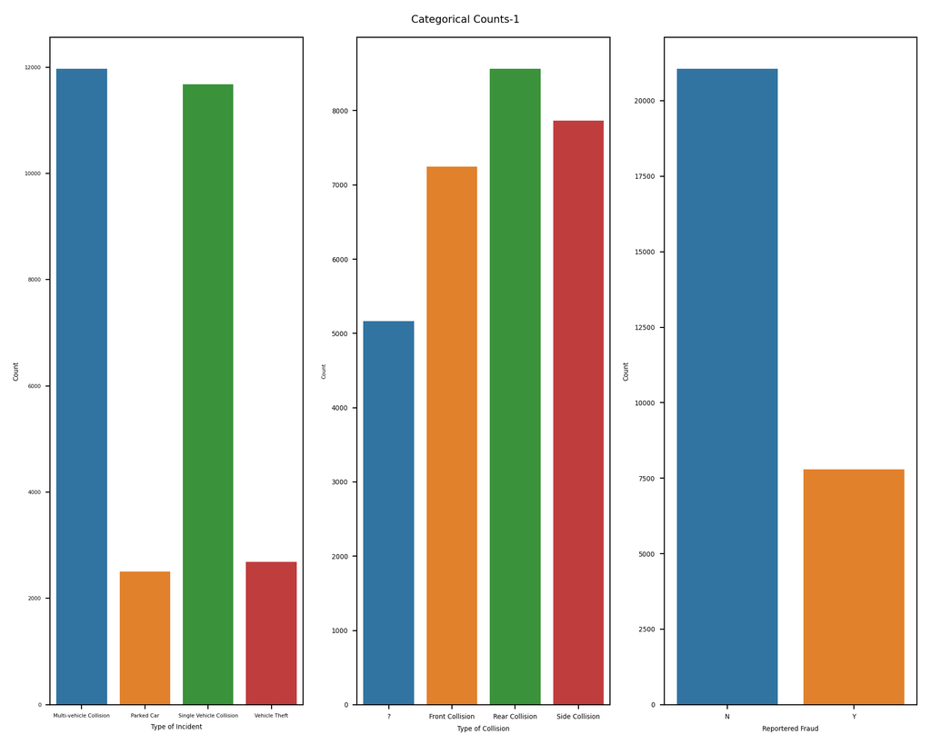

```python
gs=plt.GridSpec(1, 3)
fig=plt.figure(figsize=(10,8))
fig.suptitle('Categorical Counts-1', fontsize=8)


ax1=fig.add_subplot(gs[0, 0])
ax2=fig.add_subplot(gs[0, 1])
ax3=fig.add_subplot(gs[0,2])

#plt.title('Type of Incident',fontsize=7, y=1)
hg=sns.countplot(data = fraud_v3, x = 'TypeOfIncident', ax=ax1)
hg.tick_params(axis='both', which='major', labelsize=4)
hg.set_xlabel("Type of Incident", fontsize=5)
hg.set_ylabel("Count",fontsize=5)
#plt.title('Type of Collision',fontsize=7, y=1)
sp=sns.countplot(data=fraud_v3, x='TypeOfCollission', ax=ax2)
sp.tick_params(axis='both', which='major', labelsize=5)
sp.set_xlabel("Type of Collision", fontsize=5)
sp.set_ylabel("Count",fontsize=4)
#plt.title('Reported Fraud',fontsize=7, y=1)
bp=sns.countplot(data=fraud_v3, x='ReportedFraud', ax=ax3)
bp.tick_params(axis='both', which='major', labelsize=5)
bp.set_xlabel("Reportered Fraud", fontsize=5)
bp.set_ylabel("Count", fontsize=5)

plt.tight_layout()

plt.show()
```

```python
plt.clf()
```

Next, we’ll check the data for missing values (NAs or null) or values that are unknown. Unknown values may have terms denoting that the value is unknown or have symbols that indicate that the value is unknown.

```python
print(fraud_v3.isnull().sum())
```

```
## CustomerID                      0
## TypeOfIncident                  0
## TypeOfCollission                0
## SeverityOfIncident              0
## AuthoritiesContacted            0
## IncidentState                   0
## IncidentCity                    0
## IncidentAddress                 0
## NumberOfVehicles                0
## PropertyDamage                  0
## BodilyInjuries                  0
## Witnesses                       0
## PoliceReport                    0
## AmountOfInjuryClaim             0
## AmountOfPropertyClaim           0
## AmountOfVehicleDamage           0
## AmountOfTotalClaim              0
## InsuredAge                      0
## InsuredZipCode                  0
## InsuredGender                   0
## InsuredEducationLevel           0
## InsuredOccupation               0
## InsuredHobbies                  0
## CapitalGains                    0
## CapitalLoss                     0
## Country                         0
## InsurancePolicyNumber           0
## CustomerLoyaltyPeriod           0
## InsurancePolicyState            0
## Policy_CombinedSingleLimit      0
## Policy_Deductible               0
## PolicyAnnualPremium             0
## UmbrellaLimit                   0
## InsuredRelationship             0
## VehicleID                       0
## VehicleMake                     0
## VehicleModel                    0
## VehicleYOM                      0
## ReportedFraud                   0
## coverageIncidentDiff            0
## dayOfWeek                       0
## IncidentPeriodDay             422
## dtype: int64
```

```python
with contextlib.redirect_stderr(sys.stdout):
  my_tab=pd.crosstab(index=fraud_v3["TypeOfIncident"], columns=fraud_v3["TypeOfCollission"], normalize=True).round(2)
```

```python
fig = plt.figure(figsize=(13, 10))

sns.heatmap(my_tab, cmap="BuGn",cbar=False, annot=True,linewidth=0.3)

plt.yticks(rotation=0)
```

```
## (array([0.5, 1.5, 2.5, 3.5]), [Text(0, 0.5, 'Multi-vehicle Collision'), Text(0, 1.5, 'Parked Car'), Text(0, 2.5, 'Single Vehicle Collision'), Text(0, 3.5, 'Vehicle Theft')])
```

```python
plt.xticks(rotation=60)
```

```
## (array([0.5, 1.5, 2.5, 3.5]), [Text(0.5, 0, '?'), Text(1.5, 0, 'Front Collision'), Text(2.5, 0, 'Rear Collision'), Text(3.5, 0, 'Side Collision')])
```

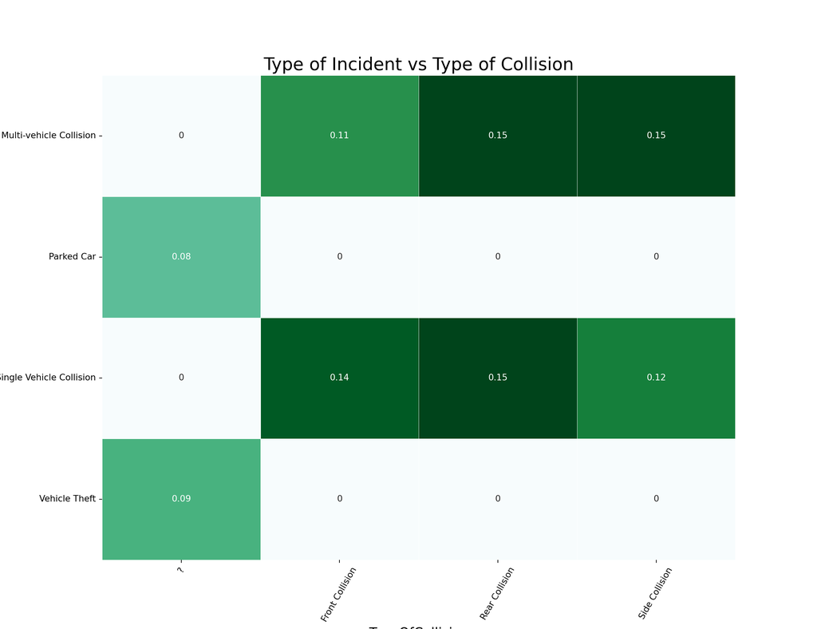

```python
plt.title('Type of Incident vs Type of Collision', fontsize=20)
plt.xlabel('TypeOfCollision', fontsize=15)
plt.ylabel('TypeOIncident', fontsize=15)

plt.show()
```

```python
plt.clf()
```

```python
fraud_v4['TypeOfCollission'] = fraud_v4['TypeOfCollission'].replace(['?'], 'None')
```

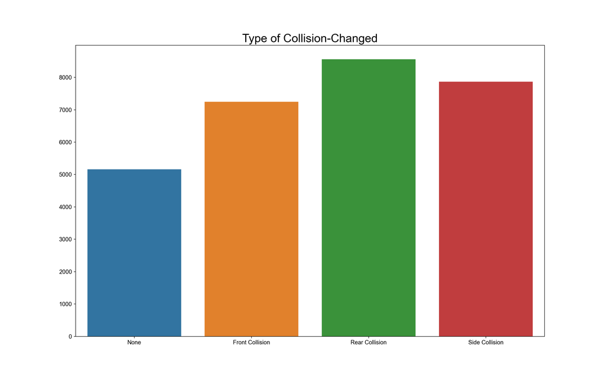

```python
plt.figure(figsize=(16,10))
#plt.title("Type of Collision-Changed")
ax=sns.countplot(data=fraud_v4, x='TypeOfCollission')
#plt.tick_params(label_rotation=45)
ax.tick_params(axis='both', which='major', labelsize=11)
ax.set_title("Type of Collision-Changed", size=22)
ax.set(xlabel=None)
ax.set(ylabel=None)
sns.set_style("dark")

ax.annotate('Figure ##',

            xy = (1.0, -0.2),

            xycoords='axes fraction',

            ha='right',

            va="center",

            fontsize=10)

fig.tight_layout()

plt.show()
```

```python
plt.clf()
```

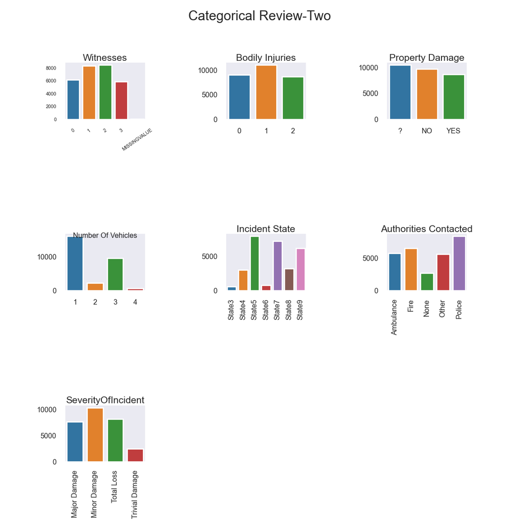

```python
fig = plt.figure(figsize=(6, 6))
fig.tight_layout(pad=1.30,h_pad=4, w_pad=3)
fig.suptitle('Categorical Review-Two', fontsize=11)
sns.set_style("dark")





plt.subplot(331)
plt.title('Witnesses', fontsize=8, y=0.90)
dt_1=sns.countplot(data = count_plts_2, x = 'Witnesses')
dt_1.tick_params(axis='both', which='major', labelsize=4)
dt_1.tick_params(axis='x',labelrotation=35)
dt_1.set(xlabel=None)
dt_1.set(ylabel=None)





plt.subplot(332)
plt.title('Bodily Injuries',fontsize=8, y=0.90)
dt_2=sns.countplot(data = count_plts_2, x = 'BodilyInjuries')
dt_2.tick_params(axis='both', which='major', labelsize=6)
#dt_2.tick_params(axis='x',labelrotation=35)
dt_2.set(xlabel=None)
dt_2.set(ylabel=None)


plt.subplot(333)
plt.title('Property Damage',fontsize=8, y=0.90)
dt_3=sns.countplot(data = count_plts_2, x = 'PropertyDamage')
dt_3.tick_params(axis='both', which='major', labelsize=6)
#dt_3.tick_params(axis='x',labelrotation=35)
dt_3.set(xlabel=None)
dt_3.set(ylabel=None)

plt.subplot(334)
plt.title('Number Of Vehicles',fontsize=6, y=0.80)
dt_4=sns.countplot(data = count_plts_2, x = 'NumberOfVehicles')
dt_4.tick_params(axis='both', which='major', labelsize=6)
#dt_4.tick_params(axis='x',labelrotation=45)
dt_4.set(xlabel=None)
dt_4.set(ylabel=None)

plt.subplot(335)
plt.title('Incident State',fontsize=8, y=0.90)
dt_5=sns.countplot(data = count_plts_2, x = 'IncidentState')
dt_5.tick_params(axis='both', which='major', labelsize=6)
dt_5.tick_params(axis='x',labelrotation=90)
dt_5.set(xlabel=None)
dt_5.set(ylabel=None)

plt.subplot(336)
plt.title('Authorities Contacted',fontsize=8, y=0.90)
dt_6=sns.countplot(data = count_plts_2, x = 'AuthoritiesContacted')
dt_6.tick_params(axis='both', which='major', labelsize=6)
dt_6.tick_params(axis='x',labelrotation=90)
dt_6.set(xlabel=None)
dt_6.set(ylabel=None)

plt.subplot(337)
plt.title('SeverityOfIncident',fontsize=8, y=0.90)
dt_7=sns.countplot(data = count_plts_2, x ='SeverityOfIncident')
dt_7.tick_params(axis='both', which='major', labelsize=6)
dt_7.tick_params(axis='x',labelrotation=90)
dt_7.set(xlabel=None)
dt_7.set(ylabel=None)


plt.subplots_adjust(wspace=01.0, hspace=2.0)

plt.show()
```

```python
plt.clf()
```

From the figure Categorical Review 2 we detect certain features that must be dealt with due to missing values. First, the property damage feature will be dropped due to many observations having no answer which is denoted by a question mark.

```python
fraud_v5=fraud_v5.drop(['PropertyDamage'], axis=1)
```

Next, the category MISSINGVALUE from the Witnesses feature will be dropped.

```python
fraud_v5['Witnesses']=fraud_v5['Witnesses'].cat.remove_categories("MISSINGVALUE")
```

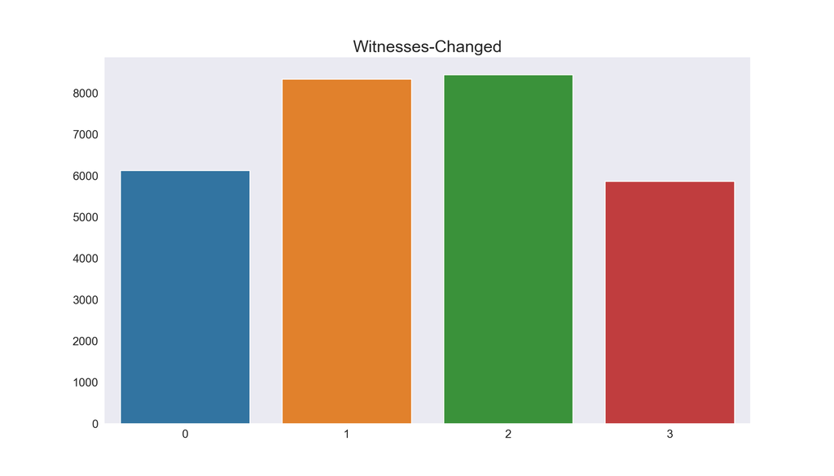

```python
plt.figure(figsize=(14,8))
#plt.title("Type of Collision-Changed")
ax=sns.countplot(data=fraud_v5, x='Witnesses')
#plt.tick_params(label_rotation=45)
ax.set_title("Witnesses-Changed", size=20)
ax.set(xlabel=None)
ax.set(ylabel=None)
ax.tick_params(axis='both', which='major', labelsize=14)
sns.set_style("dark")

ax.annotate('Figure ##',

            xy = (1.0, -0.2),

            xycoords='axes fraction',

            ha='right',

            va="center",

            fontsize=10)

fig.tight_layout()

plt.show()
```

```python
plt.clf()
```

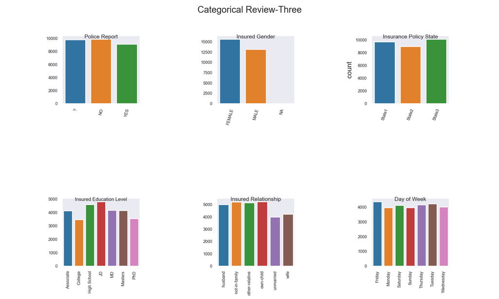

```python
fig = plt.figure(figsize=(10, 6))
fig.tight_layout(pad=1.40,h_pad=4, w_pad=3)
fig.suptitle('Categorical Review-Three', fontsize=13)
sns.set_style("dark")





plt.subplot(231)
plt.title('Police Report', fontsize=8, y=0.90)
et_1=sns.countplot(data = count_plts_3, x = 'PoliceReport')
et_1.tick_params(axis='both', which='major', labelsize=6)
et_1.tick_params(axis='x',labelrotation=75)
et_1.set(xlabel=None)
et_1.set(ylabel=None)






plt.subplot(232)
plt.title('Insured Gender',fontsize=8, y=0.90)
et_2=sns.countplot(data = count_plts_3, x = 'InsuredGender')
et_2.tick_params(axis='both', which='major', labelsize=6)
et_2.tick_params(axis='x',labelrotation=75)
et_2.set(xlabel=None)
et_2.set(ylabel=None)



plt.subplot(233)
plt.title('Insurance Policy State',fontsize=8, y=0.90)
et_4=sns.countplot(data = count_plts_3, x = 'InsurancePolicyState')
et_4.tick_params(axis='both', which='major', labelsize=6)
et_4.tick_params(axis='x',labelrotation=70)
et_4.set(xlabel=None)

plt.subplot(234)
plt.title('Insured Education Level',fontsize=7, y=0.90)
et_3=sns.countplot(data = count_plts_3, x = 'InsuredEducationLevel')
et_3.tick_params(axis='both', which='major', labelsize=6)
et_3.tick_params(axis='x',labelrotation=90)
et_3.set(xlabel=None)
et_3.set(ylabel=None)

plt.subplot(235)
plt.title('Insured Relationship',fontsize=8, y=0.90)
et_5=sns.countplot(data = count_plts_3, x = 'InsuredRelationship')
et_5.tick_params(axis='both', which='major', labelsize=6)
et_5.tick_params(axis='x',labelrotation=90)
et_5.set(xlabel=None)
et_5.set(ylabel=None)



plt.subplot(236)
plt.title('Day of Week',fontsize=8, y=0.90)
et_6=sns.countplot(data = count_plts_3, x = 'dayOfWeek')
et_6.tick_params(axis='both', which='major', labelsize=6)
et_6.tick_params(axis='x',labelrotation=90)
et_6.set(xlabel=None)
et_6.set(ylabel=None)


plt.subplots_adjust(wspace=01.0, hspace=1.4)

plt.show()
```

```python
plt.clf()
```

```python
fraud_v5['Witnesses']=fraud_v5['Witnesses'].cat.remove_unused_categories()
```

Categorical Review 3 informs us that there are additional categorical features which must be either cleaned or dropped. First, the feature “Police Report” has close to 10000 missing or unknown values (denoted by a question mark). This feature will be dropped.

```python
fraud_v6=fraud_v6.drop(['PoliceReport'], axis=1)
```

The next feature requiring attention is InsuredGender. There are a small number of missing values, denoted by NA. This category will be removed from InsuredGender. The omission of this small count category will have no effect on our models.

```python
fraud_v6['InsuredGender']=fraud_v6['InsuredGender'].cat.remove_categories("NA")
```

```python
fraud_v6['InsuredGender']=fraud_v6['InsuredGender'].cat.remove_unused_categories()
```

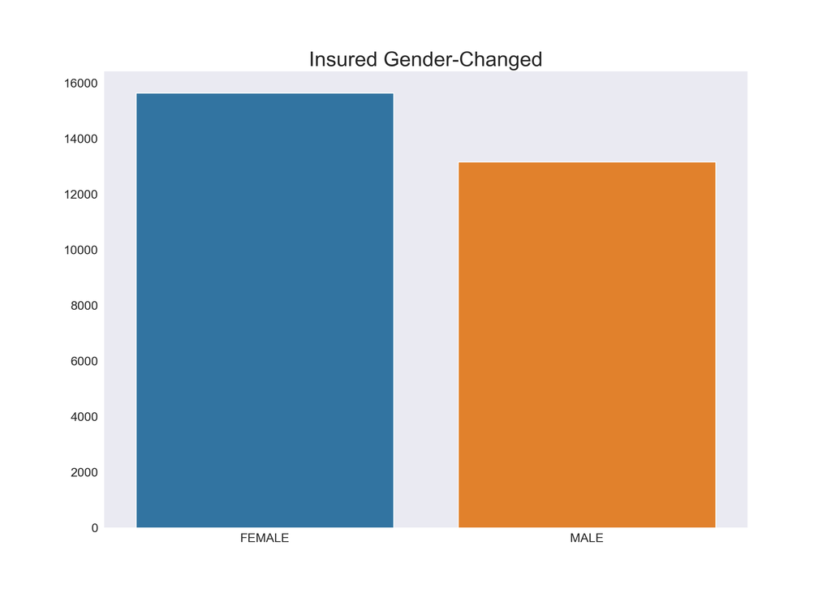

```python
plt.figure(figsize=(14,10))
#plt.title("Type of Collision-Changed")
ax=sns.countplot(data=fraud_v6, x='InsuredGender')
#plt.tick_params(label_rotation=45)
ax.set_title("Insured Gender-Changed", size=25)
ax.set(xlabel=None)
ax.set(ylabel=None)
ax.tick_params(axis='both',labelsize = 15)
sns.set_style("dark")

ax.annotate('Figure ##',

            xy = (1.0, -0.2),

            xycoords='axes fraction',

            ha='right',

            va="center",

            fontsize=10)

fig.tight_layout()

plt.show()
```

```python
plt.clf()
```

```
## *******premium_missing shape*******
```

```
## (141, 40)
```

```
## *******fraud_v6 shape*******
```

```
## (28836, 40)
```

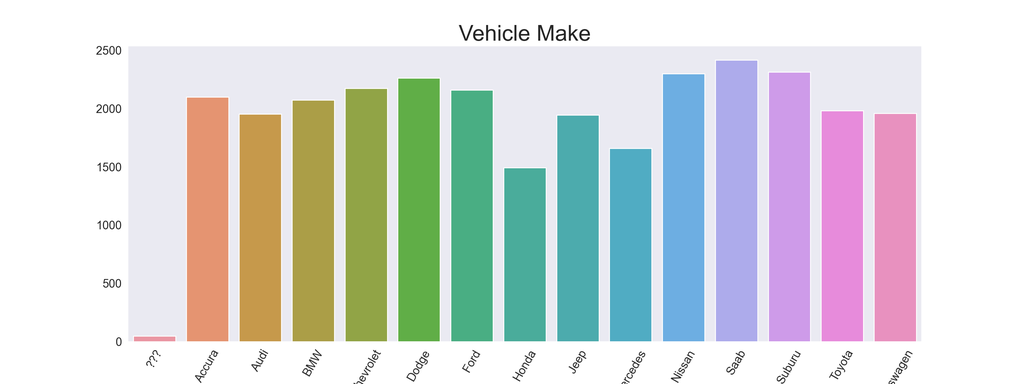

```python
plt.figure(figsize=(16,6))

ax=sns.countplot(data=fraud_v6, x='VehicleMake')

ax.set_title("Vehicle Make", size=25)
ax.set(xlabel=None)
ax.set(ylabel=None)
ax.tick_params(axis='x',labelrotation=60,labelsize =13)
ax.tick_params(axis='y', labelsize=13)
sns.set_style("dark")

ax.annotate('Figure ##',

            xy = (1.0, -0.2),

            xycoords='axes fraction',

            ha='right',

            va="center",

            fontsize=10)

fig.tight_layout()

plt.show()
```

```python
plt.clf()
```

VehicleMake has a small number of missing values (denoted by ‘???’). The category ‘???’ will be removed from the feature.

```python
fraud_v7['VehicleMake']=fraud_v7['VehicleMake'].cat.remove_categories("???")
```

```python
fraud_v7['VehicleMake']=fraud_v7['VehicleMake'].cat.remove_unused_categories()
```

```python
veh_mk=vehicle_count.groupby('VehicleMake')['count'].agg('count').reset_index()
```

```python
plt.figure(figsize=(12,8))

fig, axes=plt.subplots()

line_colors=['blue', 'cyan', 'green', 'red','skyblue','maroon', 'salmon', 'yellow',
            'orange','lightgreen','darkviolet', 'fuchsia','darkmagenta','lime' ]

axes.hlines(veh_mk['VehicleMake'], xmin=0,
            xmax=veh_mk['count'],colors=line_colors)

axes.plot(veh_mk['count'],veh_mk['VehicleMake'],"o")

axes.set_xlim(0)
```

```
## (0.0, 2535.75)
```

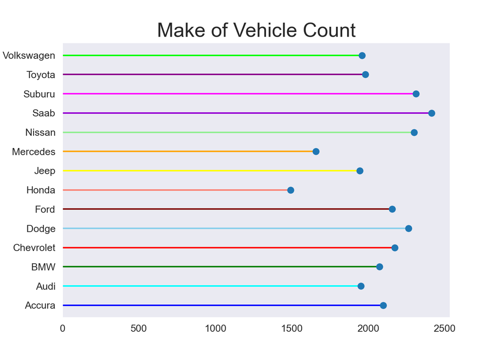

```python
axes.tick_params(axis='both', which='major', labelsize=10)
plt.title('Make of Vehicle Count', fontsize=20)

plt.show()
```

```python
plt.clf()
```

VechicleMake feature now has no missing values.

Filtering for any PolicyAnnualPremium value that is equal to -1 we find 141 values returned. From the Attribute Information pdf provided with the data set we know that -1 represents a missing value. All observations with -1 will be removed.

```python
fraud_v7=fraud_v7[fraud_v7['PolicyAnnualPremium']!=-1]
```

```python
print('**Policy Annual Premium Shape**')
```

```
## **Policy Annual Premium Shape**
```

```python
fraud_v7[fraud_v7['PolicyAnnualPremium']==-1].shape
```

```
## (0, 40)
```

From the shape output we can observe all values of -1 have been removed.

Certain visualizations require numeric only data. We’ll create a date set that contains only numeric data types.

```python
#select only the numeric columns in the DataFrame

numeric_data=fraud_v7.select_dtypes(include=np.number)
```

```python
numeric_data=numeric_data.drop(['InsuredZipCode', 'InsurancePolicyNumber'], axis=1)
```

```
## ******************Numeric Data Types******************
```

```
## AmountOfInjuryClaim        int32
## AmountOfPropertyClaim      int32
## AmountOfVehicleDamage      int32
## AmountOfTotalClaim         int32
## InsuredAge                 int32
## CapitalGains               int32
## CapitalLoss                int32
## CustomerLoyaltyPeriod      int32
## Policy_Deductible          int32
## PolicyAnnualPremium      float64
## UmbrellaLimit              int32
## coverageIncidentDiff     float64
## dtype: object
```

The data set numeric_data only includes features of numeric data types as seen from the above output.

## Visualization

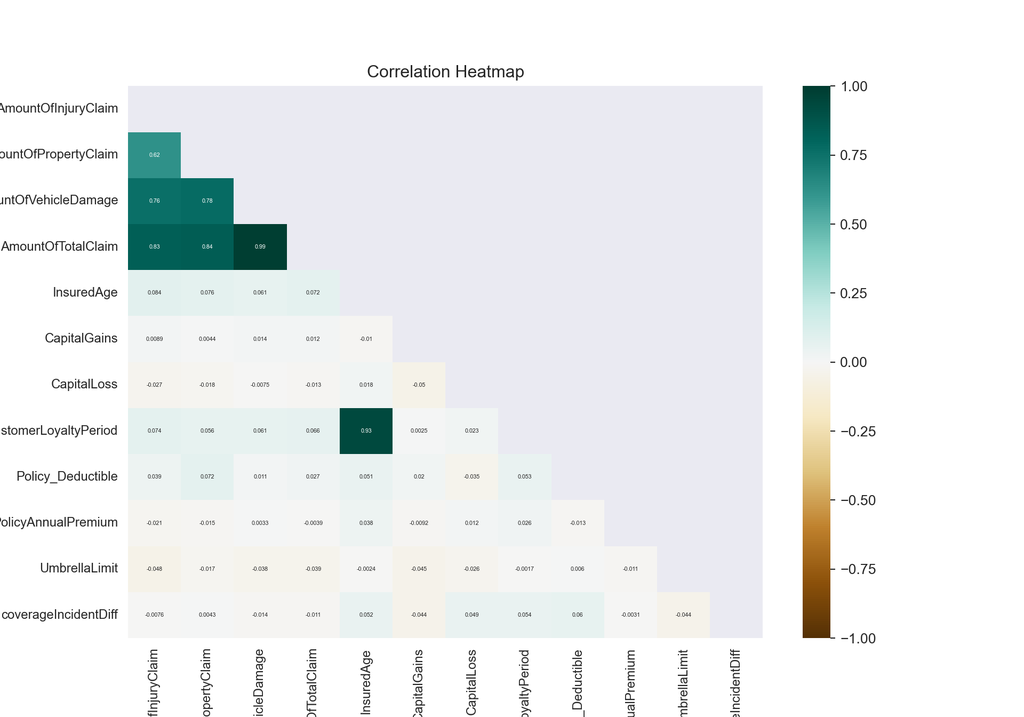

```python
plt.figure(figsize=(10, 7))




plt.tick_params(axis='both', which='major', labelsize=9)



plt.title('Correlation Heatmap', fontsize=12)

# define the mask to set the values in the upper triangle to Truemask

mask=np.triu(np.ones_like(numeric_data.corr(), dtype=bool))

# Generate a custom diverging colormap

#cmap = sns.diverging_palette(220, 10, as_cmap=True)

#ht_mp=sns.heatmap(fraud_train_v8.corr(), cmap=cmap, vmax=.3, center=0,annot=True,
            #square=True, linewidths=.5, cbar_kws={"shrink": .5})


heatmap = sns.heatmap(numeric_data.corr(), mask=mask,vmin=-1, vmax=1, annot=True, cmap='BrBG', annot_kws={"size": 4})

plt.show()
```

```python
plt.clf()
```

There is very high to high correlation between Amount of Injury Claim, Amount of Property Claim, Amount of Vehicle Damage, and Amount of Total Claim. This is unsurprising as Amount of Total Claim is the sum of the other three. Amount of Total Claim is the only feature of the four that will be used for our machine learning models.

Other features exhibiting very high correlation are Loyalty period and Age. This makes sense as older customers have the chance to accrue loyalty time based on having lived longer than younger customers. Still, we will retain both features for our models.

Features not important for visualizing or building models will now be dropped.

```python
fraud_v8=fraud_v8.drop(['CustomerID', 'IncidentAddress', 'InsuredZipCode', 'InsuredHobbies','Country', 'InsurancePolicyNumber', 'VehicleID'], axis=1)
```

```
## **fraud_v8 shape**
```

```
## (28695, 33)
```

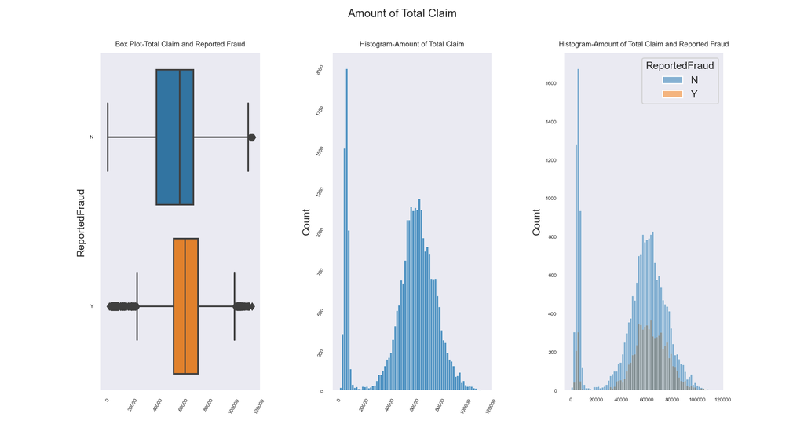

```python
fig = plt.figure(figsize=(11, 6))
fig.suptitle('Amount of Total Claim', fontsize=11)

sns.set_style("dark")


plt.subplot(131)
plt.title('Box Plot-Total Claim and Reported Fraud', fontsize=7)
ac_1=sns.boxplot(data = fraud_v8, x = "AmountOfTotalClaim", y='ReportedFraud')
ac_1.tick_params(axis='x', which='major', labelsize=5)
ac_1.tick_params(axis='y', labelsize=5)
ac_1.tick_params(axis='x', labelrotation=60)
ac_1.set(xlabel=None)



plt.subplot(132)
plt.title('Histogram-Amount of Total Claim', fontsize=7)
ac_2=sns.histplot(data=fraud_v8, x="AmountOfTotalClaim")
ac_2.tick_params(axis='x', which='major', labelsize=5)
ac_2.tick_params(labelrotation=60)
ac_2.tick_params(axis='y', labelsize=5)
ac_2.set(xlabel=None)



plt.subplot(133)
plt.title('Histogram-Amount of Total Claim and Reported Fraud', fontsize=7)
ac_3=sns.histplot(data=fraud_v8, x="AmountOfTotalClaim", hue="ReportedFraud")
ac_3.tick_params(axis='x', which='major', labelsize=5)
ac_3.tick_params(axis='y', labelsize=5)

ac_3.set(xlabel=None)



plt.subplots_adjust(wspace=0.45)

plt.show()
```

```python
plt.clf()
```

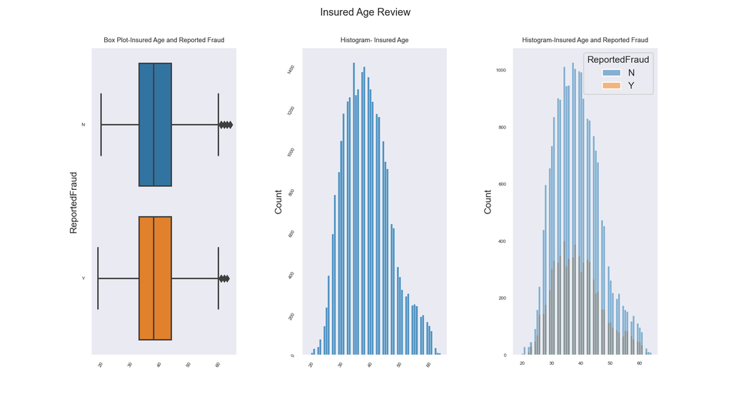

```python
fig = plt.figure(figsize=(11, 6))
fig.suptitle('Insured Age Review', fontsize=11)

sns.set_style("dark")


plt.subplot(131)
plt.title('Box Plot-Insured Age and Reported Fraud', fontsize=7)
ia_1=sns.boxplot(data = fraud_v8, x = "InsuredAge", y='ReportedFraud')
ia_1.tick_params(axis='x', which='major', labelsize=5)
ia_1.tick_params(axis='y', labelsize=5)
ia_1.tick_params(axis='x', labelrotation=60)
ia_1.set(xlabel=None)



plt.subplot(132)
plt.title('Histogram- Insured Age', fontsize=7)
ia_2=sns.histplot(data=fraud_v8, x="InsuredAge")
ia_2.tick_params(axis='x', which='major', labelsize=5)
ia_2.tick_params(labelrotation=60)
ia_2.tick_params(axis='y', labelsize=5)
ia_2.set(xlabel=None)



plt.subplot(133)
plt.title('Histogram-Insured Age and Reported Fraud', fontsize=7)
ia_3=sns.histplot(data=fraud_v8, x="InsuredAge",hue="ReportedFraud")
ia_3.tick_params(axis='x', which='major', labelsize=5)
ia_3.tick_params(axis='y', labelsize=5)

ia_3.set(xlabel=None)



plt.subplots_adjust(wspace=0.45)

plt.show()
```

```python
plt.clf()
```

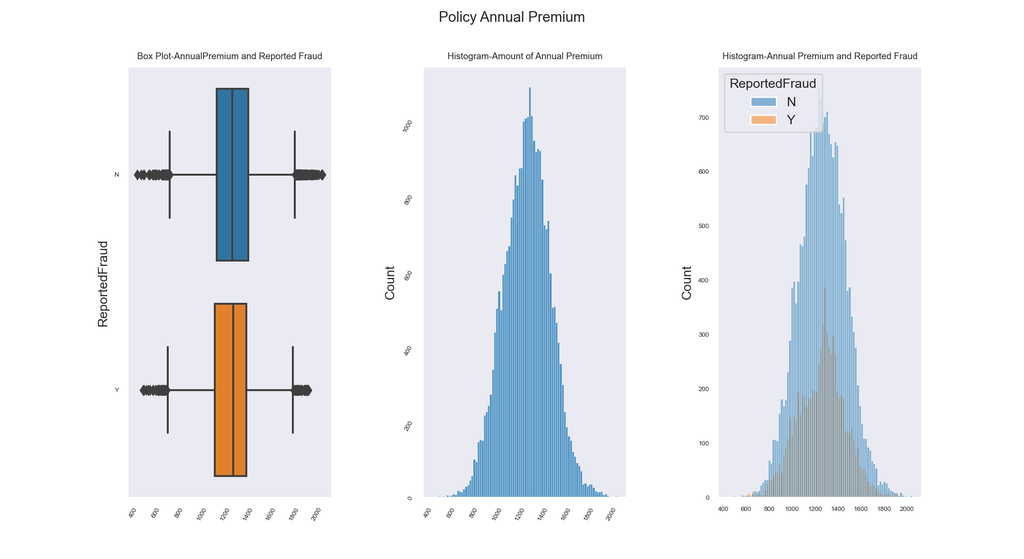

```python
fig = plt.figure(figsize=(11, 6))
fig.suptitle('Policy Annual Premium', fontsize=11)

sns.set_style("dark")






plt.subplot(131)
plt.title('Box Plot-AnnualPremium and Reported Fraud', fontsize=7)
ac_1=sns.boxplot(data = fraud_v8, x = "PolicyAnnualPremium", y='ReportedFraud')
ac_1.tick_params(axis='x', which='major', labelsize=5)
ac_1.tick_params(axis='y', labelsize=5)
ac_1.tick_params(axis='x', labelrotation=60)
ac_1.set(xlabel=None)



plt.subplot(132)
plt.title('Histogram-Amount of Annual Premium', fontsize=7)
ac_2=sns.histplot(data=fraud_v8, x="PolicyAnnualPremium")
ac_2.tick_params(axis='x', which='major', labelsize=5)
ac_2.tick_params(labelrotation=60)
ac_2.tick_params(axis='y', labelsize=5)
ac_2.set(xlabel=None)



plt.subplot(133)
plt.title('Histogram-Annual Premium and Reported Fraud', fontsize=7)
ac_3=sns.histplot(data=fraud_v8, x="PolicyAnnualPremium", hue="ReportedFraud")
ac_3.tick_params(axis='x', which='major', labelsize=5)
ac_3.tick_params(axis='y', labelsize=5)

ac_3.set(xlabel=None)



plt.subplots_adjust(wspace=0.45)

plt.show()
```

```python
plt.clf()
```

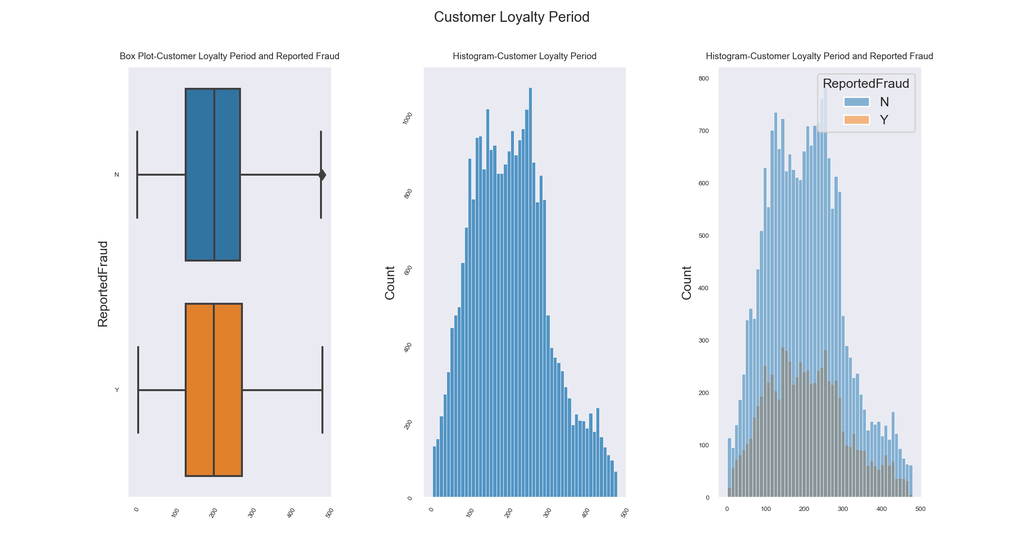

```python
fig = plt.figure(figsize=(11, 6))
fig.suptitle('Customer Loyalty Period', fontsize=11)

sns.set_style("dark")






plt.subplot(131)
plt.title('Box Plot-Customer Loyalty Period and Reported Fraud', fontsize=7)
ac_1=sns.boxplot(data = fraud_v8, x = "CustomerLoyaltyPeriod", y='ReportedFraud')
ac_1.tick_params(axis='x', which='major', labelsize=5)
ac_1.tick_params(axis='y', labelsize=5)
ac_1.tick_params(axis='x', labelrotation=60)
ac_1.set(xlabel=None)



plt.subplot(132)
plt.title('Histogram-Customer Loyalty Period', fontsize=7)
ac_2=sns.histplot(data=fraud_v8, x="CustomerLoyaltyPeriod")
ac_2.tick_params(axis='x', which='major', labelsize=5)
ac_2.tick_params(labelrotation=60)
ac_2.tick_params(axis='y', labelsize=5)
ac_2.set(xlabel=None)



plt.subplot(133)
plt.title('Histogram-Customer Loyalty Period and Reported Fraud', fontsize=7)
ac_3=sns.histplot(data=fraud_v8, x="CustomerLoyaltyPeriod", hue="ReportedFraud")
ac_3.tick_params(axis='x', which='major', labelsize=5)
ac_3.tick_params(axis='y', labelsize=5)

ac_3.set(xlabel=None)



plt.subplots_adjust(wspace=0.45)

plt.show()
```

```python
plt.clf()
```

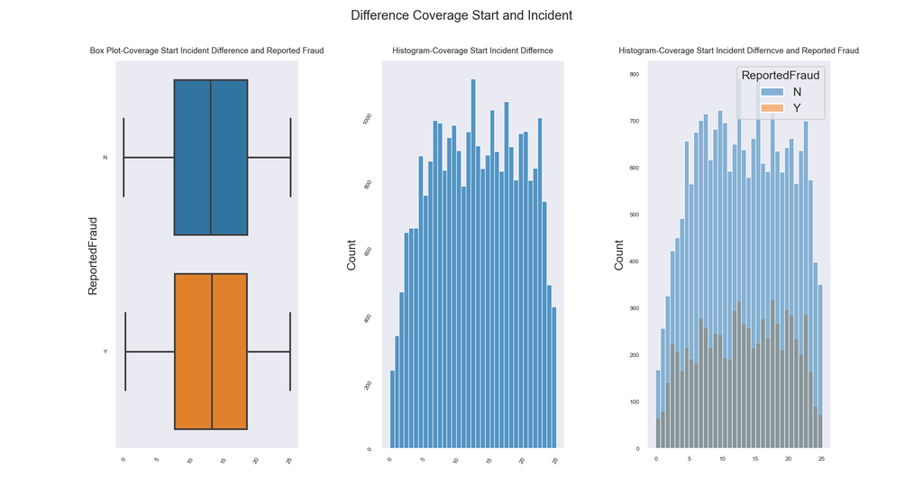

```python
fig = plt.figure(figsize=(11, 6))
fig.suptitle('Difference Coverage Start and Incident', fontsize=11)

sns.set_style("dark")






plt.subplot(131)
plt.title('Box Plot-Coverage Start Incident Difference and Reported Fraud', fontsize=7)
ac_1=sns.boxplot(data = fraud_v8, x = "coverageIncidentDiff", y='ReportedFraud')
ac_1.tick_params(axis='x', which='major', labelsize=5)
ac_1.tick_params(axis='y', labelsize=5)
ac_1.tick_params(axis='x', labelrotation=60)
ac_1.set(xlabel=None)



plt.subplot(132)
plt.title('Histogram-Coverage Start Incident Differnce', fontsize=7)
ac_2=sns.histplot(data=fraud_v8, x="coverageIncidentDiff")
ac_2.tick_params(axis='x', which='major', labelsize=5)
ac_2.tick_params(labelrotation=60)
ac_2.tick_params(axis='y', labelsize=5)
ac_2.set(xlabel=None)



plt.subplot(133)
plt.title('Histogram-Coverage Start Incident Differncve and Reported Fraud', fontsize=7)
ac_3=sns.histplot(data=fraud_v8, x="coverageIncidentDiff", hue="ReportedFraud")
ac_3.tick_params(axis='x', which='major', labelsize=5)
ac_3.tick_params(axis='y', labelsize=5)

ac_3.set(xlabel=None)



plt.subplots_adjust(wspace=0.45)

plt.show()
```

```python
plt.clf()
```

```
## **** Year Of Make****
```

```
## 2015     416
## 1995     531
## 1996     828
## 2014     871
## 1997    1131
## 2013    1256
## 1998    1276
## 2012    1308
## 2001    1428
## 1999    1479
## 2011    1518
## 2000    1523
## 2002    1527
## 2003    1571
## 2008    1622
## 2009    1623
## 2010    1631
## 2005    1635
## 2006    1637
## 2004    1661
## 2007    1709
## Name: VehicleYOM, dtype: int64
```

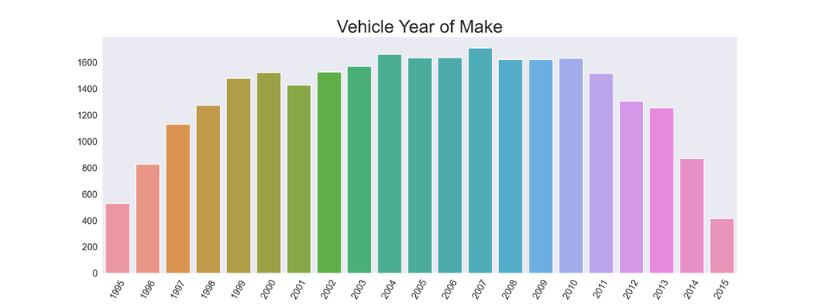

```python
plt.figure(figsize=(16,6))

ax=sns.countplot(data=fraud_v8, x='VehicleYOM')

ax.set_title("Vehicle Year of Make", size=25)
ax.set(xlabel=None)
ax.set(ylabel=None)
ax.tick_params(axis='x',labelrotation=60,labelsize =13)
ax.tick_params(axis='y', labelsize=13)
sns.set_style("dark")

ax.annotate('Figure ##',

            xy = (1.0, -0.2),

            xycoords='axes fraction',

            ha='right',

            va="center",

            fontsize=10)

fig.tight_layout()

plt.show()
```

```python
plt.clf()
```

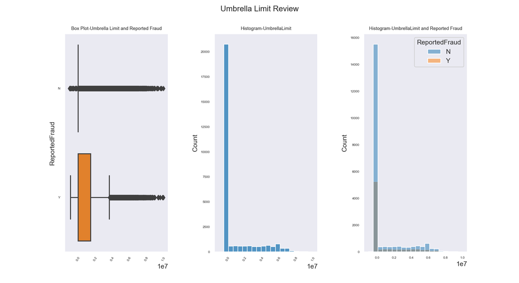

```python
fig = plt.figure(figsize=(11, 6))
fig.suptitle('Umbrella Limit Review', fontsize=12)
sns.set_style("dark")




plt.subplot(131)
plt.title('Box Plot-Umbrella Limit and Reported Fraud', fontsize=7)
ul_1=sns.boxplot(data = fraud_v8, x = "UmbrellaLimit", y='ReportedFraud')
ul_1.tick_params(axis='x', which='major', labelsize=5)
ul_1.tick_params(axis='y', labelsize=5)
ul_1.tick_params(axis='x', labelrotation=60)
ul_1.set(xlabel=None)



plt.subplot(132)
plt.title('Histogram-UmbrellaLimit', fontsize=7)
ul_2=sns.histplot(data=fraud_v8, x="UmbrellaLimit",bins=20)
ul_2.tick_params(axis='x', which='major', labelsize=5)
ul_2.tick_params(axis='x',labelrotation=60)
ul_2.tick_params(axis='y', labelsize=5)
ul_2.set(xlabel=None)



plt.subplot(133)
plt.title('Histogram-UmbrellaLimit and Reported Fraud', fontsize=7)
ul_3=sns.histplot(data=fraud_v8, x="UmbrellaLimit",hue='ReportedFraud',bins=20)
ul_3.tick_params(axis='x', which='major', labelsize=5)
ul_3.tick_params(axis='y', labelsize=5)
ul_3.set(xlabel=None)



plt.subplots_adjust(wspace=0.45)

plt.show()
```

```python
plt.clf()
```

The above plots are unusual. Both box plots have a median of zero. Reported Fraud=Y has a mean of 1,000,000 while Reported Fraud=“N” mean is 918,000. Both histograms have their peak at zero and a log tail to the right.

There are only 7506 data points greater than zero. 2417 for Yes and 5089 for No. Data points greater than zero represent only 26 percent of the entire data set. Normally this would seem unusual, and we would review the raw data for errors. Checking the description of umbrella limit we find that such extreme data points are not uncommon. Umbrella insurance provides “excess liability insurance” beyond the liability insurance already in auto insurance coverage. It’s for expensive situations where medical bills and/or repairs exceed those in “base” auto policies. Auto policy holders who fall in the higher income brackets are usually the purchasers of umbrella limit. Thus, for all data points, the mean of 972,000 and max of 10,000,000 are common values. Additionally, the mean of zero is not unsurprising as not many insured choose umbrella limits for their policies.

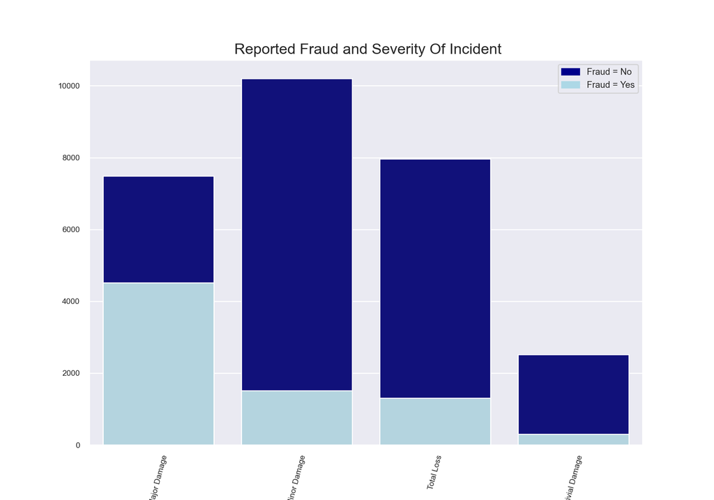

```python
sns.set(style="darkgrid")

plt.figure(figsize=(10, 7))

# top bar -> sum all values(ReportedFraud=No and      # ReportedFraud=Yes) to find y position of the bars
total = fraud_v8.groupby('SeverityOfIncident')['count'].sum().reset_index()



# bar chart 1 -> top bars (group of #'ReportedFraud=No')
bar1 = sns.barplot(x="SeverityOfIncident",  y="count", data=total, color='darkblue')

# bottom bar ->  take only ReportedFraud=Yes values #from the data
fraud = fraud_v8[fraud_v8.ReportedFraud=='Y']

# bar chart 2 -> bottom bars (group of #'ReportedFraud=Yes')
bar2 = sns.barplot(x="SeverityOfIncident", y="count", data=fraud, estimator=sum, errorbar=None,  color='lightblue')

# add legend
top_bar = mpatches.Patch(color='darkblue', label='Fraud = No')
bottom_bar = mpatches.Patch(color='lightblue', label='Fraud = Yes')
plt.legend(handles=[top_bar, bottom_bar],fontsize=9, loc="upper right")



plt.tick_params(axis='x', which='major', labelsize=8, labelrotation=75)

plt.tick_params(axis='y', which='major', labelsize=8)



plt.title(" Reported Fraud and Severity Of Incident", fontsize=15)
plt.xlabel(None)
plt.ylabel(None)

plt.show()
```

```python
plt.clf()
```

The above plot displays bar plots of categories belonging to the feature ‘severity of incident’ stacked based on whether fraud is ‘Y’ or ‘N’. ‘Major Damage’ stands out as 60% of claims are reported as fraud whereas the other categories have claims reported as fraud under 16%.

```python
with contextlib.redirect_stderr(sys.stdout):
  grouped_veh_mk=fraud_v8.groupby(['VehicleMake','ReportedFraud']).agg({'count':'sum'})
```

```python
grouped_veh_mk_perc=grouped_veh_mk.groupby(level=0, group_keys=False).apply(lambda x: x /x.sum()).round(2)
```

```python
grouped_veh_mk_perc.rename(columns={'count':'Percent'}, inplace=True)
```

```python
#Convert from multi index to single index.

grouped_veh_mk_perc_single=grouped_veh_mk_perc.reset_index(level=[1])
```

```python
grouped_veh_mk_perc_single=grouped_veh_mk_perc_single.reset_index()
```

```python
#Pivot wider. This makes "Y" and "N" seperate columns
grouped_veh_mk_perc_wide=grouped_veh_mk_perc_single.pivot(index='VehicleMake',columns='ReportedFraud',values='Percent').reset_index()
```

```python
#Reorder df following 'N'

grouped_veh_mk_ordered=grouped_veh_mk_perc_wide.sort_values(by='N')
```

```python
my_range=range(1,len(grouped_veh_mk_ordered.index)+1)
```

```python
plt.figure(figsize=(9, 9))

plt.hlines(y=my_range, xmin=grouped_veh_mk_ordered['N'], xmax=grouped_veh_mk_ordered['Y'], color='grey', alpha=0.4)
plt.scatter(grouped_veh_mk_ordered['N'], my_range, color='skyblue', alpha=1, label='N')
plt.scatter(grouped_veh_mk_ordered['Y'], my_range, color='green', alpha=0.4 , label='Y')
plt.legend(title="Reported Fraud", loc="lower right", title_fontsize=18,fontsize=6, borderpad=0, facecolor="wheat")

plt.yticks(my_range, grouped_veh_mk_ordered['VehicleMake'])
```

[output not shown]

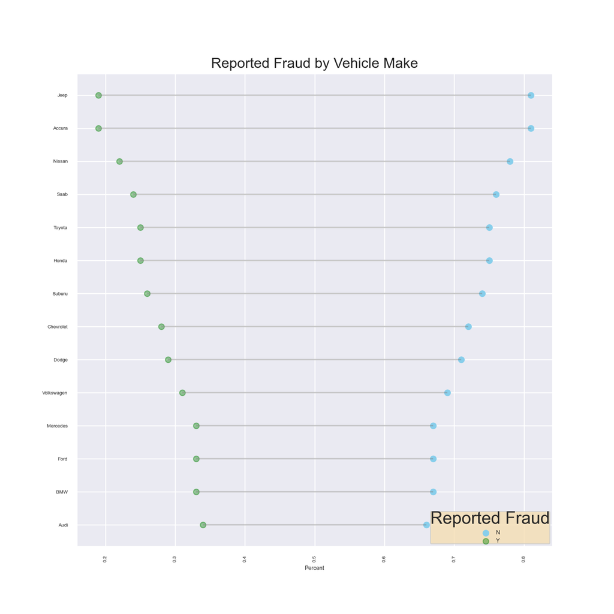

```python
plt.title("Reported Fraud by Vehicle Make", fontsize=15,loc='center')
plt.xlabel('Percent', fontsize=6)
plt.ylabel(None)


plt.tick_params(axis='x', which='major', labelsize=5, labelrotation=90)

plt.tick_params(axis='y', which='major', labelsize=5)

plt.show()
```

```python
plt.clf()
```

We find that Volkswagen, Mercedes, Ford, BMW, and Audi are the vehicle makes with reported fraud over 30%. This is an interesting statistic though due to the large number of categories we’ll explore the ‘Vehicle Make’ feature further.

Due to the number of categories of “Vehicle Make” we will exclude it from the modeling process.

```python
grouped_inc_st=fraud_v8.groupby(['IncidentState','ReportedFraud']).agg({'count':'sum'})
```

```python
grouped_inc_st_perc=grouped_inc_st.groupby(level=0, group_keys=False).apply(lambda x: x /x.sum()).round(2)



#numeric_only
```

```python
grouped_inc_st_perc.rename(columns={'count':'Percent'}, inplace=True)
```

```python
grouped_inc_st_perc_single=grouped_inc_st_perc.reset_index(level=[1])
```

```python
grouped_inc_st_perc_single=grouped_inc_st_perc_single.reset_index()
```

```python
grouped_inc_st_perc_wide=grouped_inc_st_perc_single.pivot(index='IncidentState',columns='ReportedFraud',values='Percent').reset_index()
```

```python
grouped_inc_st_ordered=grouped_inc_st_perc_wide.sort_values(by='N')
```

```python
my_range_2=range(1,len(grouped_inc_st_ordered.index)+1)
```

```python
plt.figure(figsize=(13, 13))

plt.hlines(y=my_range_2, xmin=grouped_inc_st_ordered['N'], xmax=grouped_inc_st_ordered['Y'], color='grey', alpha=0.4)
plt.scatter(grouped_inc_st_ordered['N'], my_range_2, color='skyblue', alpha=1, label='N')
plt.scatter(grouped_inc_st_ordered['Y'], my_range_2, color='green', alpha=0.4 , label='Y')
plt.legend(title="Reported Fraud", loc="lower right", title_fontsize=8,fontsize=6, borderpad=0, facecolor="wheat")

plt.yticks(my_range_2, grouped_inc_st_ordered['IncidentState'])
```

[output not shown]

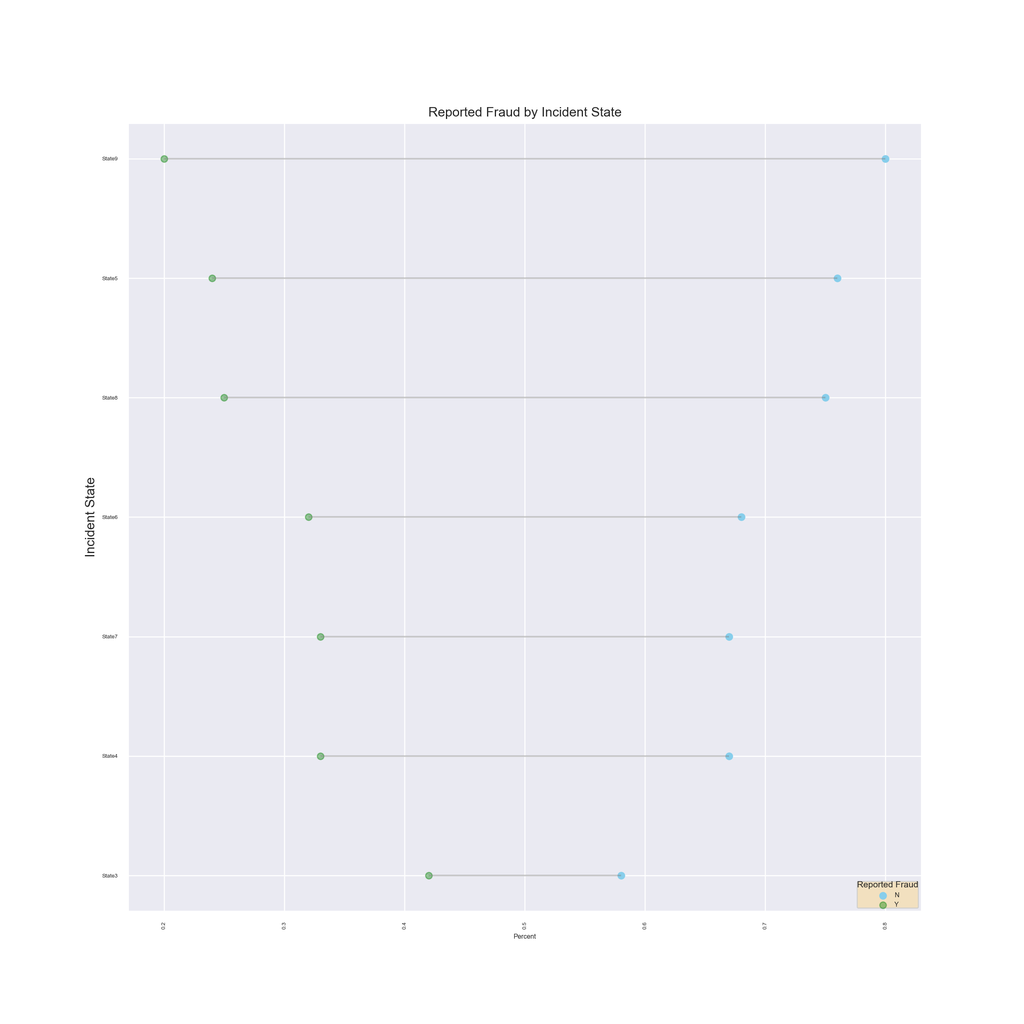

```python
plt.title("Reported Fraud by Incident State", loc='center')
plt.xlabel('Percent', fontsize=6)
plt.ylabel('Incident State')


plt.tick_params(axis='x', which='major', labelsize=5, labelrotation=90)

plt.tick_params(axis='y', which='major', labelsize=5)

plt.show()
```

```python
plt.clf()
```

Incident States 4,6, and 7 have reported fraud just over 30% which appears significant. However, Incident state 3 stands out from the other states with a reported fraud around 42%

```python
grouped_type_inc=fraud_v8.groupby(['TypeOfIncident','ReportedFraud']).agg({'count':'sum'})
```

```python
grouped_type_inc_perc=grouped_type_inc.groupby(level=0, group_keys=False).apply(lambda x: x /x.sum()).round(2)
```

```python
grouped_type_inc_perc.rename(columns={'count':'Percent'}, inplace=True)
```

```python
grouped_type_inc_perc_single=grouped_type_inc_perc.reset_index(level=[1])
```

```python
grouped_type_inc_perc_single=grouped_type_inc_perc_single.reset_index()
```

```python
grouped_type_inc_perc_wide=grouped_type_inc_perc_single.pivot(index='TypeOfIncident',columns='ReportedFraud',values='Percent').reset_index()
```

```python
grouped_type_inc_ordered=grouped_type_inc_perc_wide.sort_values(by='N')
```

```python
my_range_3=range(1,len(grouped_type_inc_ordered.index)+1)
```

```python
plt.figure(figsize=(13, 13))

plt.hlines(y=my_range_3, xmin=grouped_type_inc_ordered['N'], xmax=grouped_type_inc_ordered['Y'], color='grey', alpha=0.4)
plt.scatter(grouped_type_inc_ordered['N'], my_range_3, color='skyblue', alpha=1, label='N')
plt.scatter(grouped_type_inc_ordered['Y'], my_range_3, color='green', alpha=0.4 , label='Y')
plt.legend(title="Reported Fraud", loc="lower right", title_fontsize=8,fontsize=6, borderpad=0, facecolor="wheat")

plt.yticks(my_range_3, grouped_type_inc_ordered['TypeOfIncident'])
```

[output not shown]

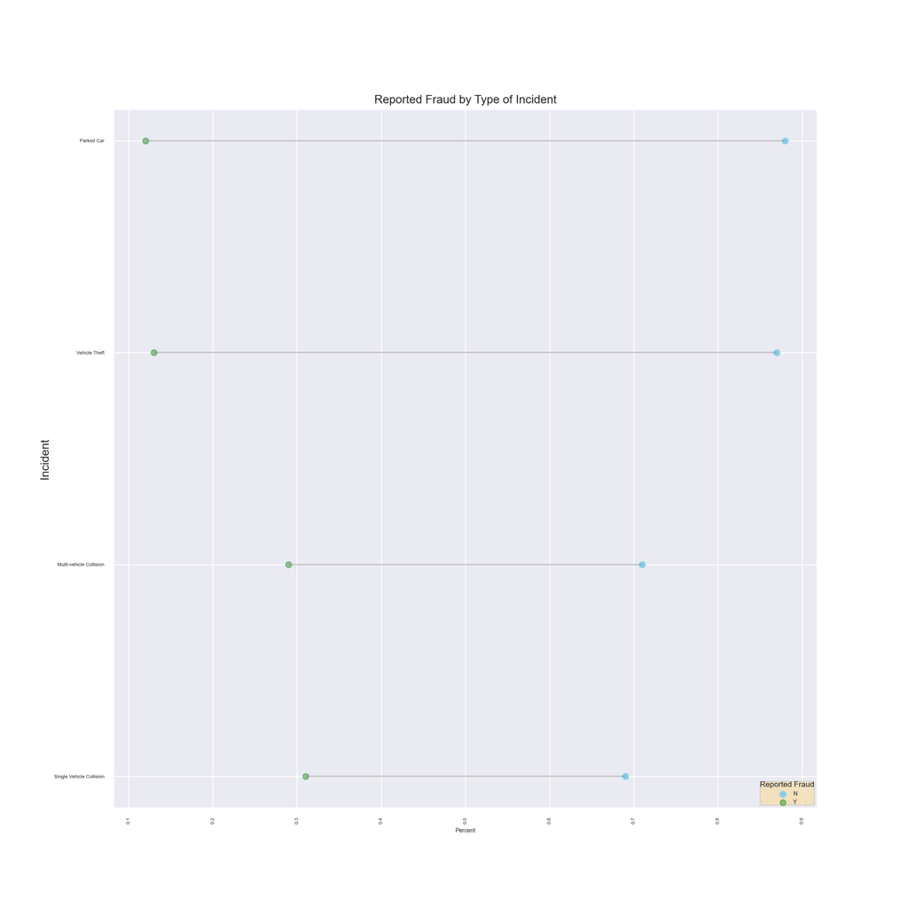

```python
plt.title("Reported Fraud by Type of Incident", loc='center')
plt.xlabel('Percent', fontsize=6)
plt.ylabel('Incident')

plt.tick_params(axis='x', which='major', labelsize=5, labelrotation=90)

plt.tick_params(axis='y', which='major', labelsize=5)

plt.show()
```

```python
plt.clf()
```

From the above plots we observe two categories stand out with respect to reported fraud. ‘Single Vehicle Collision’ and ‘Multi-vehicle collision’ from the feature ‘Type of Incident’ have claims reported as fraud at 31% and 29% respectively. The other two categories are under 14%.

## Outliers

We’ll now review our data for outliers. Our goal is not necessarily to remove observations that are indicated as outliers, it is to derive insights that may help us understand reported fraud in combination with our machine learning models.

### Numertic Review

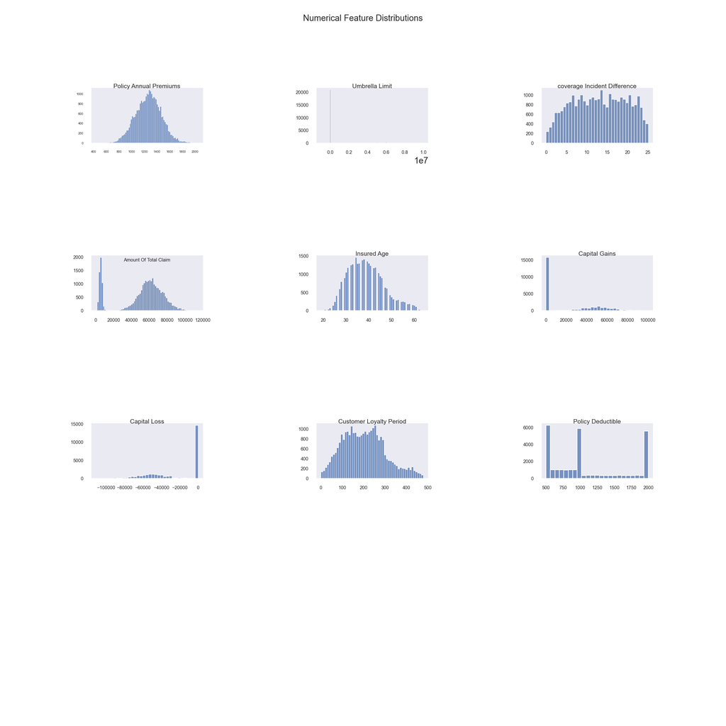

```python
fig = plt.figure(figsize=(13, 13))
fig.tight_layout(pad=1.30,h_pad=4, w_pad=3)
fig.suptitle('Numerical Feature Distributions', fontsize=11)
sns.set_style("dark")





plt.subplot(431)
plt.title('Policy Annual Premiums',fontsize=8, y=0.90)
dt_1=sns.histplot(data = numeric_data, x ='PolicyAnnualPremium')
dt_1.tick_params(axis='both', which='major', labelsize=4)
#dt_1.tick_params(axis='x',labelrotation=35)
dt_1.set(xlabel=None)
dt_1.set(ylabel=None)





plt.subplot(432)
plt.title('Umbrella Limit',fontsize=8, y=0.90)
dt_2=sns.histplot(data = numeric_data, x ='UmbrellaLimit')
dt_2.tick_params(axis='both', which='major', labelsize=6)
#dt_2.tick_params(axis='x',labelrotation=35)
dt_2.set(xlabel=None)
dt_2.set(ylabel=None)


plt.subplot(433)
plt.title('coverage Incident Difference',fontsize=8, y=0.90)
dt_3=sns.histplot(data = numeric_data, x ='coverageIncidentDiff')
dt_3.tick_params(axis='both', which='major', labelsize=6)
#dt_3.tick_params(axis='x',labelrotation=35)
dt_3.set(xlabel=None)
dt_3.set(ylabel=None)

plt.subplot(434)
plt.title('Amount Of Total Claim',fontsize=6, y=0.80)
dt_4=sns.histplot(data = numeric_data, x = 'AmountOfTotalClaim')
dt_4.tick_params(axis='both', which='major', labelsize=6)
#dt_4.tick_params(axis='x',labelrotation=45)
dt_4.set(xlabel=None)
dt_4.set(ylabel=None)

plt.subplot(435)
plt.title('Insured Age',fontsize=8, y=0.90)
dt_5=sns.histplot(data = numeric_data, x = 'InsuredAge')
dt_5.tick_params(axis='both', which='major', labelsize=6)
#dt_5.tick_params(axis='x',labelrotation=90)
dt_5.set(xlabel=None)
dt_5.set(ylabel=None)

plt.subplot(436)
plt.title('Capital Gains',fontsize=8, y=0.90)
dt_6=sns.histplot(data = numeric_data, x = 'CapitalGains')
dt_6.tick_params(axis='both', which='major', labelsize=6)
#dt_6.tick_params(axis='x',labelrotation=90)
dt_6.set(xlabel=None)
dt_6.set(ylabel=None)

plt.subplot(437)
plt.title('Capital Loss',fontsize=8, y=0.90)
dt_7=sns.histplot(data = numeric_data, x ='CapitalLoss')
dt_7.tick_params(axis='both', which='major', labelsize=6)
#dt_7.tick_params(axis='x',labelrotation=90)
dt_7.set(xlabel=None)
dt_7.set(ylabel=None)

plt.subplot(438)
plt.title('Customer Loyalty Period',fontsize=8, y=0.90)
dt_8=sns.histplot(data = numeric_data, x ='CustomerLoyaltyPeriod')
dt_8.tick_params(axis='both', which='major', labelsize=6)
#dt_7.tick_params(axis='x',labelrotation=90)
dt_8.set(xlabel=None)
dt_8.set(ylabel=None)

plt.subplot(439)
plt.title('Policy Deductible',fontsize=8, y=0.90)
dt_9=sns.histplot(data = numeric_data, x ='Policy_Deductible')
dt_9.tick_params(axis='both', which='major', labelsize=6)
#dt_7.tick_params(axis='x',labelrotation=90)
dt_9.set(xlabel=None)
dt_9.set(ylabel=None)





plt.subplots_adjust(wspace=01.0, hspace=2.0)

plt.show()
```

```python
plt.clf()
```

The above plots indicate that certain numerical features exhibit distributions that are not normal this we will zoom in on these features.

```python
n_bins=np.sqrt(len(numeric_data))
```

Cast to an integer

```python
n_bins=int(n_bins)
```

```python
integers_um=range(len(numeric_data["UmbrellaLimit"]))
```

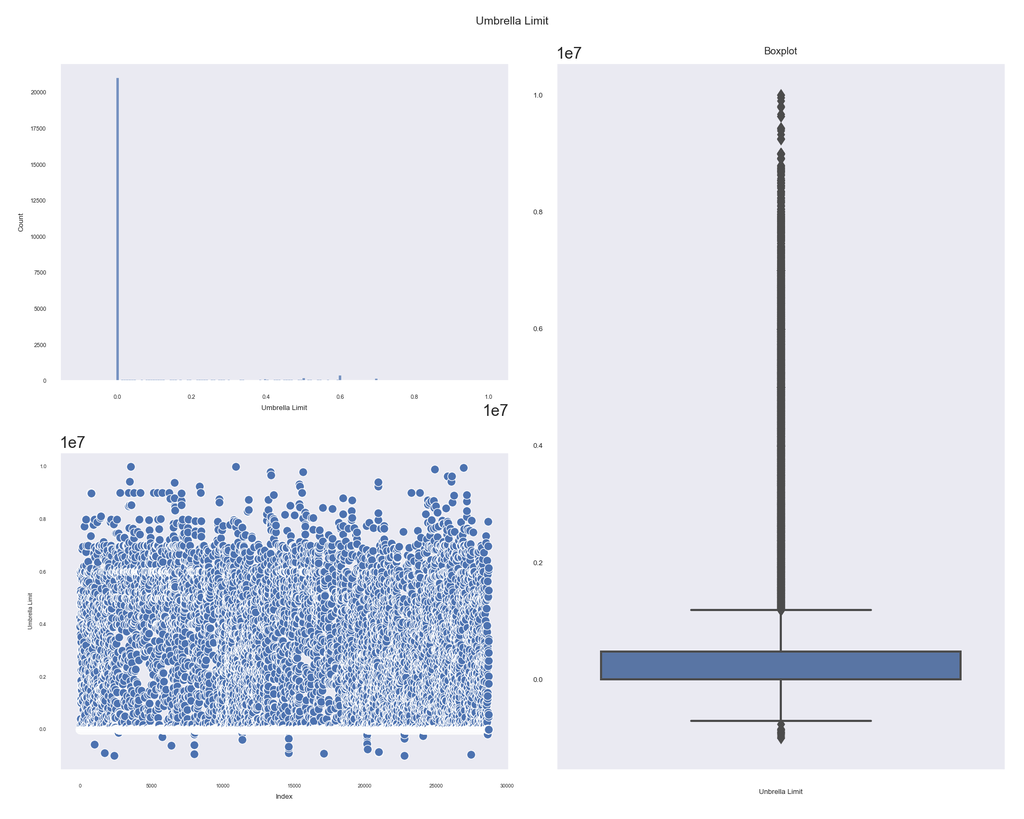

```python
gs=plt.GridSpec(2, 2)
fig=plt.figure(figsize=(10,8))
fig.suptitle('Umbrella Limit', fontsize=8)


ax1=fig.add_subplot(gs[0, 0])
ax2=fig.add_subplot(gs[1, 0])
ax3=fig.add_subplot(gs[:, 1])

#plt.title('Histogram',fontsize=7, y=1)
hg=sns.histplot(data = numeric_data, x = 'UmbrellaLimit', bins=n_bins,ax=ax1)
hg.tick_params(axis='both', which='major', labelsize=4)
hg.set_xlabel("Umbrella Limit", fontsize=5)
hg.set_ylabel("Count",fontsize=5)
#plt.title('Scatter Plot',fontsize=7, y=1)
sp=sns.scatterplot(data=numeric_data, x=integers_um, y='UmbrellaLimit', ax=ax2)
sp.tick_params(axis='both', which='major', labelsize=3.5)
sp.set_xlabel("Index", fontsize=5)
sp.set_ylabel("Umbrella Limit",fontsize=4)
plt.title('Boxplot',fontsize=7, y=1)
bp=sns.boxplot(data=numeric_data, y='UmbrellaLimit', ax=ax3)
bp.tick_params(axis='both', which='major', labelsize=5)
bp.set_xlabel("Unbrella Limit", fontsize=5)
bp.set_ylabel(None)

plt.tight_layout()

plt.show()
```

```python
plt.clf()
```

The right tail shows many bars with a height of nearly zero, far off from the bulk of the histogram. This suggests they might be outliers.

The scatter plot, we see many suspicious points that are around 0.9 . The boxplot has points above 0.1 that may be outliers.

```python
integers_tc=range(len(numeric_data["AmountOfTotalClaim"]))
```

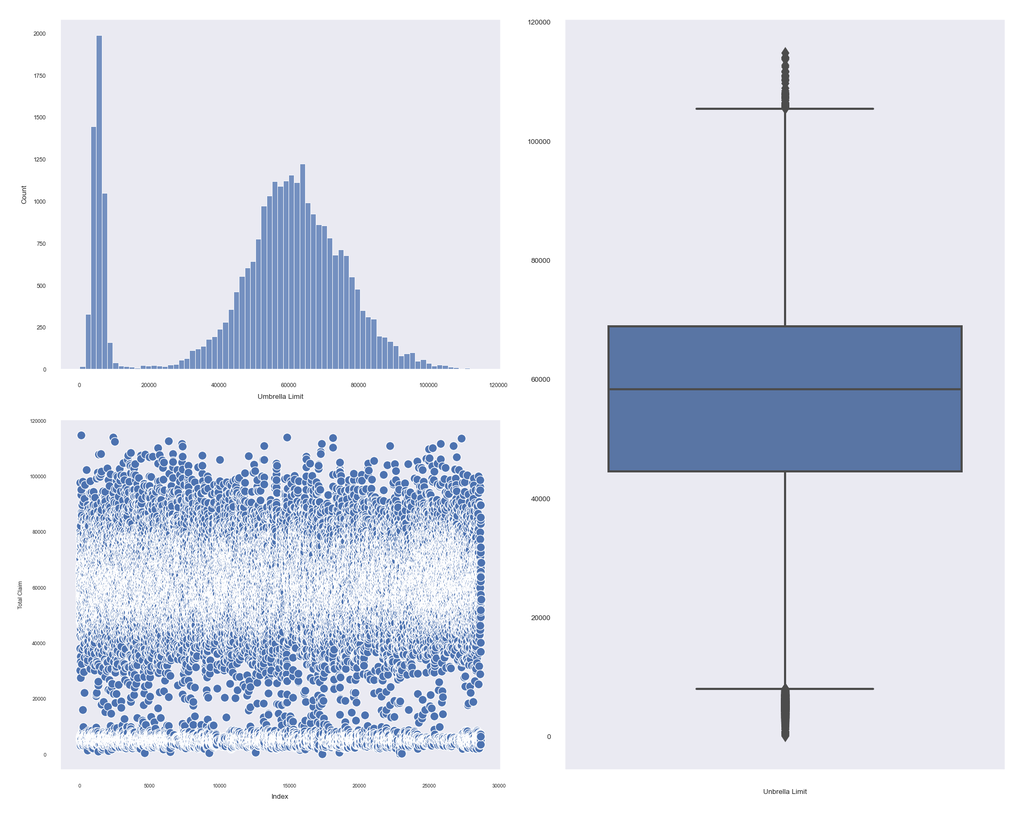

```python
gs=plt.GridSpec(2, 2)
fig=plt.figure(figsize=(10,8))


ax1=fig.add_subplot(gs[0, 0])
ax2=fig.add_subplot(gs[1, 0])
ax3=fig.add_subplot(gs[:, 1])

hg=sns.histplot(data = numeric_data, x = 'AmountOfTotalClaim', ax=ax1)
hg.tick_params(axis='both', which='major', labelsize=4)
hg.set_xlabel("Umbrella Limit", fontsize=5)
hg.set_ylabel("Count",fontsize=5)
sp=sns.scatterplot(data=numeric_data, x=integers_tc, y="AmountOfTotalClaim", ax=ax2)
sp.tick_params(axis='both', which='major', labelsize=3.5)
sp.set_xlabel("Index", fontsize=5)
sp.set_ylabel("Total Claim",fontsize=4)
bp=sns.boxplot(data=numeric_data, y="AmountOfTotalClaim", ax=ax3)
bp.tick_params(axis='both', which='major', labelsize=5)
bp.set_xlabel("Unbrella Limit", fontsize=5)
bp.set_ylabel(None)

plt.tight_layout()
plt.show()
```

```python
plt.clf()
```

```
## ******Total Claim Description******
```

```
## count     28695.000000
## mean      52303.964733
## std       25109.177907
## min         150.000000
## 25%       44612.500000
## 50%       58362.000000
## 75%       68975.500000
## max      114920.000000
## Name: AmountOfTotalClaim, dtype: float64
```

```python
print("Ten smallest Total Claim Amounts\n",numeric_data['AmountOfTotalClaim'].nsmallest(10))
```

```
## Ten smallest Total Claim Amounts
##  17433    150
## 17427    313
## 23140    334
## 22996    489
## 4654     547
## 9308     598
## 17430    681
## 18674    725
## 23136    812
## 12639    838
## Name: AmountOfTotalClaim, dtype: int32
```

```python
print("Ten Largest Total Claim Amounts\n",numeric_data['AmountOfTotalClaim'].nlargest(10))
```

```
## Ten Largest Total Claim Amounts
##  97       114920
## 2421     114141
## 14909    114113
## 18186    113997
## 27450    113771
## 6396     112817
## 2535     112560
## 7357     111870
## 25936    111771
## 17390    111708
## Name: AmountOfTotalClaim, dtype: int32
```

```python
integers_cg=range(len(numeric_data["CapitalGains"]))
```

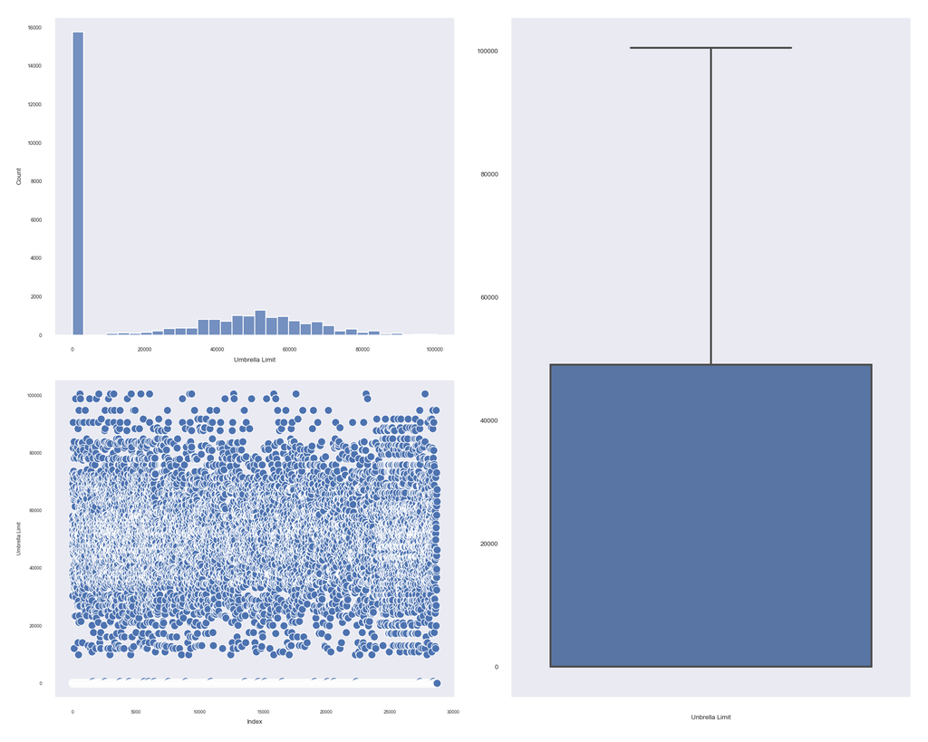

```python
gs=plt.GridSpec(2, 2)
fig=plt.figure(figsize=(10,8))


ax1=fig.add_subplot(gs[0, 0])
ax2=fig.add_subplot(gs[1, 0])
ax3=fig.add_subplot(gs[:, 1])

hg=sns.histplot(data = numeric_data, x = "CapitalGains", ax=ax1)
hg.tick_params(axis='both', which='major', labelsize=4)
hg.set_xlabel("Umbrella Limit", fontsize=5)
hg.set_ylabel("Count",fontsize=5)
sp=sns.scatterplot(data=numeric_data, x=integers_cg, y="CapitalGains", ax=ax2)
sp.tick_params(axis='both', which='major', labelsize=3.5)
sp.set_xlabel("Index", fontsize=5)
sp.set_ylabel("Umbrella Limit",fontsize=4)
bp=sns.boxplot(data=numeric_data, y="CapitalGains", ax=ax3)
bp.tick_params(axis='both', which='major', labelsize=5)
bp.set_xlabel("Unbrella Limit", fontsize=5)
bp.set_ylabel(None)

plt.tight_layout()


plt.show()
```

```python
plt.clf()
```

```
## Capital Gains Desciption
##  count     28695.000000
## mean      23074.225475
## std       27638.373450
## min           0.000000
## 25%           0.000000
## 50%           0.000000
## 75%       49000.000000
## max      100500.000000
## Name: CapitalGains, dtype: float64
```

```
## Ten smallest Capital Gain Amounts
##  4     0
## 5     0
## 11    0
## 12    0
## 14    0
## 15    0
## 16    0
## 17    0
## 18    0
## 23    0
## Name: CapitalGains, dtype: int32
```

```
## Ten Largest Capital Gain Amounts
##  593      100500
## 2064     100500
## 3000     100500
## 3274     100500
## 4642     100500
## 5423     100500
## 6093     100500
## 9284     100500
## 9420     100500
## 12750    100500
## Name: CapitalGains, dtype: int32
```

```python
integers_cl=range(len(numeric_data["CapitalLoss"]))
```

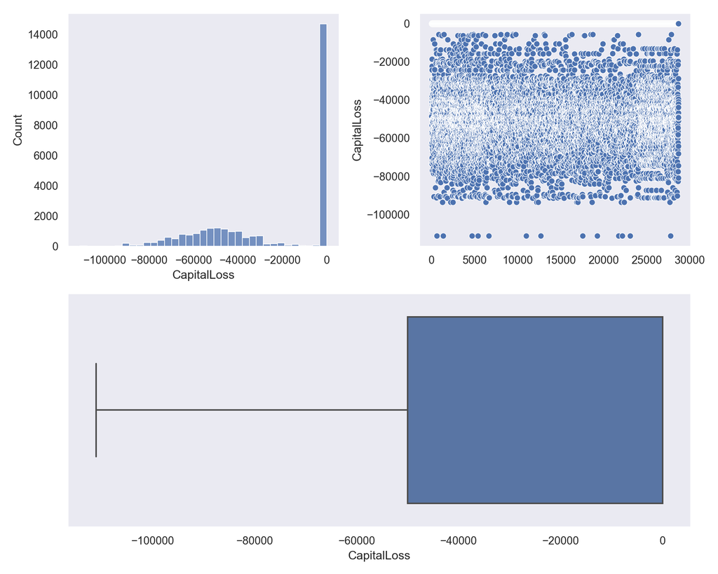

```python
gs=plt.GridSpec(2, 2)
fig=plt.figure(figsize=(10,8))


ax1=fig.add_subplot(gs[0, 0])
ax2=fig.add_subplot(gs[0, 1])
ax3=fig.add_subplot(gs[1, :])

sns.histplot(data = numeric_data, x = "CapitalLoss", ax=ax1)
sns.scatterplot(data=numeric_data, x=integers_cl, y="CapitalLoss", ax=ax2)
sns.boxplot(data=numeric_data, x="CapitalLoss", ax=ax3)

plt.tight_layout()

plt.show()
```

```python
plt.clf()
```

```python
print("Capital Loss Description\n", numeric_data["CapitalLoss"].describe())
```

```
## Capital Loss Description
##  count     28695.000000
## mean     -24942.289597
## std       27919.212327
## min     -111100.000000
## 25%      -50000.000000
## 50%           0.000000
## 75%           0.000000
## max           0.000000
## Name: CapitalLoss, dtype: float64
```

```python
print("Ten smallest Capital Loss Amounts\n",numeric_data["CapitalLoss"].nsmallest(10))
```

```
## Ten smallest Capital Loss Amounts
##  583     -111100
## 584     -111100
## 1341    -111100
## 4691    -111100
## 5417    -111100
## 6658    -111100
## 11041   -111100
## 12724   -111100
## 12725   -111100
## 12726   -111100
## Name: CapitalLoss, dtype: int32
```

```python
print("Ten Largest Capital Loss Amounts\n",numeric_data["CapitalLoss"].nlargest(10))
```

```
## Ten Largest Capital Loss Amounts
##  6     0
## 7     0
## 9     0
## 11    0
## 12    0
## 13    0
## 14    0
## 18    0
## 22    0
## 23    0
## Name: CapitalLoss, dtype: int32
```

The scatter plot has points near -100000 that may be outliers. This seems to be the case in the histogram as we see points in the tail that are possible outliers. We find a larger difference between the minimum value of 111,100 and 25 percent quantile. Checking the ten lowest values we see that the number 111,100 occupies all ten, thus it’s likely that these are not outliers.

```python
integers_pd=range(len(numeric_data["Policy_Deductible"]))
```

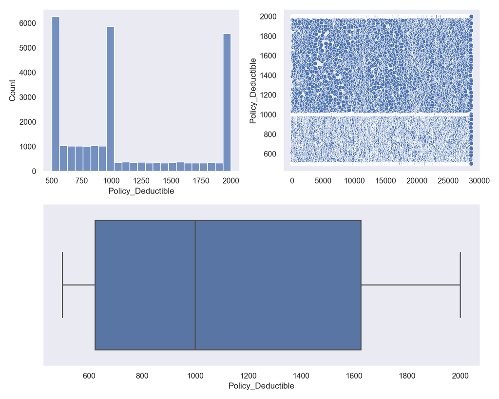

```python
gs=plt.GridSpec(2, 2)
fig=plt.figure(figsize=(10,8))


ax1=fig.add_subplot(gs[0, 0])
ax2=fig.add_subplot(gs[0, 1])
ax3=fig.add_subplot(gs[1, :])

sns.histplot(data = numeric_data, x = "Policy_Deductible", ax=ax1)
sns.scatterplot(data=numeric_data, x=integers_pd, y="Policy_Deductible", ax=ax2)
sns.boxplot(data=numeric_data, x="Policy_Deductible", ax=ax3)

plt.tight_layout()

plt.show()
```

```python
plt.clf()
```

```python
print("Policy Deductable description\n",numeric_data["Policy_Deductible"].describe())
```

```
## Policy Deductable description
##  count    28695.000000
## mean      1114.250671
## std        546.567184
## min        500.000000
## 25%        622.000000
## 50%       1000.000000
## 75%       1625.500000
## max       2000.000000
## Name: Policy_Deductible, dtype: float64
```

```
## Ten smallest Policy Deductable Amounts
##  4     500
## 5     500
## 10    500
## 14    500
## 15    500
## 21    500
## 22    500
## 48    500
## 49    500
## 73    500
## Name: Policy_Deductible, dtype: int32
```

```
## Ten largest Policy Deductable Amounts
##  8     2000
## 18    2000
## 27    2000
## 28    2000
## 29    2000
## 33    2000
## 36    2000
## 37    2000
## 39    2000
## 40    2000
## Name: Policy_Deductible, dtype: int32
```

### Categorical Review

We’ll check our categorical features first by viewing their distributions. We will then use boxplots to determine if any categories for a categorical features is different from the other categories across all of our chosen numeric features. Categories that exhibit differences from other categories acrros all numeric features may be outliers.

```python
fraud_v9=fraud_v8.copy()
```

```python
fraud_v9=fraud_v9.drop(['IncidentCity','AmountOfInjuryClaim', 'AmountOfPropertyClaim', 'AmountOfVehicleDamage', 'VehicleModel',
'VehicleYOM', 'count', 'InsuredEducationLevel','InsuredOccupation', 'VehicleMake'], axis=1)
```

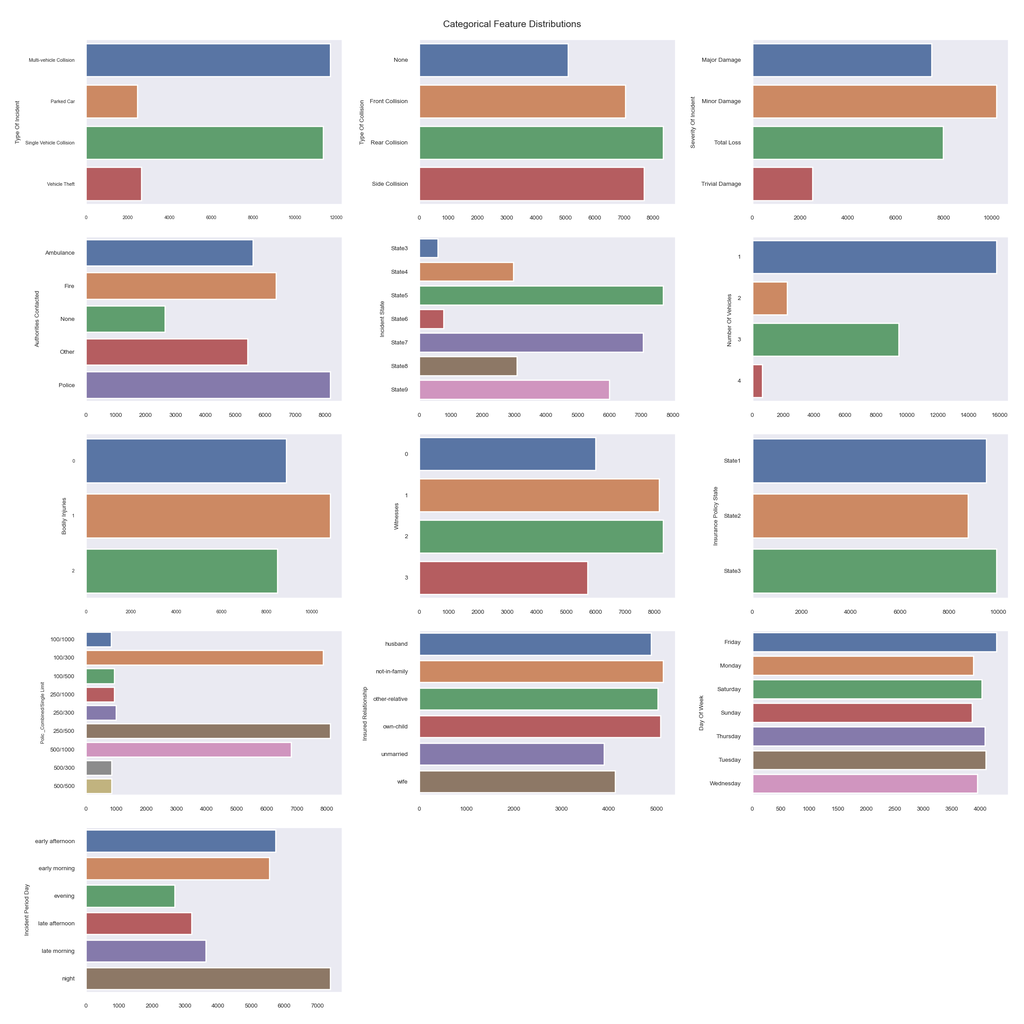

```python
gs=plt.GridSpec(5, 3)
fig=plt.figure(figsize=(12,12))
fig.suptitle('Categorical Feature Distributions', fontsize=8)


ax1=fig.add_subplot(gs[0, 0])
ax2=fig.add_subplot(gs[0, 1])
ax3=fig.add_subplot(gs[0,2])
ax4=fig.add_subplot(gs[1,0])
ax5=fig.add_subplot(gs[1,1])
ax6=fig.add_subplot(gs[1,2])
ax7=fig.add_subplot(gs[2, 0])
ax8=fig.add_subplot(gs[2, 1])
ax9=fig.add_subplot(gs[2,2])
ax10=fig.add_subplot(gs[3,0])
ax11=fig.add_subplot(gs[3,1])
ax12=fig.add_subplot(gs[3,2])
ax13=fig.add_subplot(gs[4,0])


#plt.title('Type of Incident',fontsize=7, y=1)
ct1=sns.countplot(data = fraud_v9, y='TypeOfIncident', orient='h', ax=ax1)
ct1.tick_params(axis='both', which='major', labelsize=4)
ct1.set_xlabel(None)
ct1.set_ylabel("Type Of Incident", fontsize=5)
#plt.title('Type of Collision',fontsize=7, y=1)
ct2=sns.countplot(data = fraud_v9, y='TypeOfCollission', orient='h', ax=ax2)
ct2.tick_params(axis='both', which='major', labelsize=5)
ct2.set_ylabel("Type Of Collision", fontsize=5)
ct2.set_xlabel(None)
#plt.title('Reported Fraud',fontsize=7, y=1)
ct3=sns.countplot(data=fraud_v9, y='SeverityOfIncident', orient='h', ax=ax3)
ct3.tick_params(axis='both', which='major', labelsize=5)
ct3.set_ylabel("Severity Of Incident", fontsize=5)
ct3.set_xlabel(None)
ct4=sns.countplot(data=fraud_v9, y='AuthoritiesContacted', orient='h', ax=ax4)
ct4.tick_params(axis='both', which='major', labelsize=5)
ct4.set_ylabel("Authorities Contacted", fontsize=5)
ct4.set_xlabel(None)
ct5=sns.countplot(data=fraud_v9, y='IncidentState', orient='h', ax=ax5)
ct5.tick_params(axis='both', which='major', labelsize=5)
ct5.set_ylabel('Incident State',fontsize=5)
ct5.set_xlabel(None)
ct6=sns.countplot(data=fraud_v9,y='NumberOfVehicles', orient='h', ax=ax6)
ct6.tick_params(axis='both', which='major', labelsize=5)
ct6.set_ylabel("Number Of Vehicles ", fontsize=5)
ct6.set_xlabel(None)
ct7=sns.countplot(data = fraud_v9, y='BodilyInjuries', orient='h', ax=ax7)
ct7.tick_params(axis='both', which='major', labelsize=4)
ct7.set_xlabel(None)
ct7.set_ylabel("Bodily Injuries", fontsize=5)
#plt.title('Type of Collision',fontsize=7, y=1)
ct8=sns.countplot(data = fraud_v9, y='Witnesses', orient='h', ax=ax8)
ct8.tick_params(axis='both', which='major', labelsize=5)
ct8.set_ylabel("Witnesses", fontsize=5)
ct8.set_xlabel(None)
#plt.title('Reported Fraud',fontsize=7, y=1)
ct9=sns.countplot(data=fraud_v9, y='InsurancePolicyState', orient='h', ax=ax9)
ct9.tick_params(axis='both', which='major', labelsize=5)
ct9.set_ylabel("Insurance Policy State", fontsize=5)
ct9.set_xlabel(None)
ct10=sns.countplot(data=fraud_v9, y='Policy_CombinedSingleLimit', orient='h', ax=ax10)
ct10.tick_params(axis='both', which='major', labelsize=5)
ct10.set_ylabel("Polic _Combined/Single Limit", fontsize=4)
ct10.set_xlabel(None)
ct11=sns.countplot(data=fraud_v9, y='InsuredRelationship', orient='h', ax=ax11)
ct11.tick_params(axis='both', which='major', labelsize=5)
ct11.set_ylabel('Insured Relationship ',fontsize=5)
ct11.set_xlabel(None)
ct12=sns.countplot(data=fraud_v9,y='dayOfWeek', orient='h', ax=ax12)
ct12.tick_params(axis='both', which='major', labelsize=5)
ct12.set_ylabel("Day Of Week", fontsize=5)
ct12.set_xlabel(None)
ct13=sns.countplot(data=fraud_v9,y='IncidentPeriodDay', orient='h', ax=ax13)
ct13.tick_params(axis='both', which='major', labelsize=5)
ct13.set_ylabel("Incident Period Day", fontsize=5)
ct13.set_xlabel(None)
plt.tight_layout()

plt.show()
```

```python
plt.clf()
```

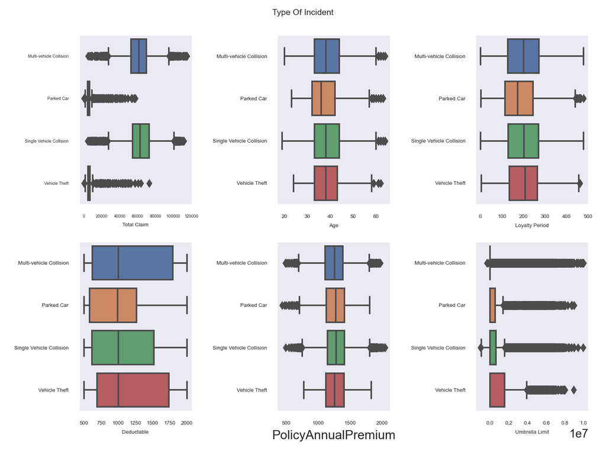

```python
gs=plt.GridSpec(2, 3)
fig=plt.figure(figsize=(8,6))
fig.suptitle('Type Of Incident', fontsize=8)


ax1=fig.add_subplot(gs[0, 0])
ax2=fig.add_subplot(gs[0, 1])
ax3=fig.add_subplot(gs[0,2])
ax4=fig.add_subplot(gs[1,0])
ax5=fig.add_subplot(gs[1,1])
ax6=fig.add_subplot(gs[1,2])

#plt.title('Type of Incident',fontsize=7, y=1)
bx1=sns.boxplot(data=fraud_v9, x='AmountOfTotalClaim', y='TypeOfIncident', orient='h', ax=ax1)
bx1.tick_params(axis='both', which='major', labelsize=4)
bx1.set_xlabel("Total Claim", fontsize=5)
bx1.set_ylabel(None)
#plt.title('Type of Collision',fontsize=7, y=1)
bx2=sns.boxplot(data=fraud_v9, x='InsuredAge', y='TypeOfIncident', orient='h', ax=ax2)
bx2.tick_params(axis='both', which='major', labelsize=5)
bx2.set_xlabel("Age", fontsize=5)
bx2.set_ylabel(None)
#plt.title('Reported Fraud',fontsize=7, y=1)
bx3=sns.boxplot(data=fraud_v9, x='CustomerLoyaltyPeriod', y='TypeOfIncident', orient='h', ax=ax3)
bx3.tick_params(axis='both', which='major', labelsize=5)
bx3.set_xlabel("Loyalty Period", fontsize=5)
bx3.set_ylabel(None)
bx4=sns.boxplot(data=fraud_v9, x='Policy_Deductible', y='TypeOfIncident', orient='h', ax=ax4)
bx4.tick_params(axis='both', which='major', labelsize=5)
bx4.set_xlabel("Deductable", fontsize=5)
bx4.set_ylabel(None)
bx5=sns.boxplot(data=fraud_v9, x='PolicyAnnualPremium', y='TypeOfIncident', orient='h', ax=ax5)
bx5.tick_params(axis='both', which='major', labelsize=5)
bx5.set_ylabel(None)
bx6=sns.boxplot(data=fraud_v9, x='UmbrellaLimit', y='TypeOfIncident', orient='h', ax=ax6)
bx6.tick_params(axis='both', which='major', labelsize=5)
bx6.set_xlabel("Umbrella Limit", fontsize=5)
bx6.set_ylabel(None)
plt.tight_layout()

plt.show()
```

```python
plt.clf()
```

Type of Incidence Boxplots we find that the categories Parked car and Vehicle Theft for Total Claim are different than the other categories though this is not consistent with our other numeric features and thus cannot make any conclusions.

No categorical features had categories that were different from the other categories across the numerical features.

### Outlier Detection Model

Convert target variable to binary (Y -> 1, N -> 0)

```python
out_mod1['ReportedFraud'] = out_mod1['ReportedFraud'].map({'Y': 1, 'N': 0})
```

```python
out_mod2=out_mod1.copy()
```

```python
out_mod2=out_mod2.drop('ReportedFraud', axis=1)
```

Identify categorical and numerical columns

```python
categorical_cols = out_mod2.select_dtypes(include=['category']).columns.tolist()
numerical_cols = out_mod2.select_dtypes(include=['int32', 'float64']).columns.tolist()
```

One-Hot Encoding for categorical variables

```python
encoder = OneHotEncoder(handle_unknown='ignore', sparse_output=False)
encoded_cats = encoder.fit_transform(out_mod2[categorical_cols])
encoded_df = pd.DataFrame(encoded_cats, columns=encoder.get_feature_names_out(categorical_cols))
```

Standardize numerical features

```python
scaler = StandardScaler()
scaled_nums = scaler.fit_transform(out_mod2[numerical_cols])
scaled_df = pd.DataFrame(scaled_nums, columns=numerical_cols)
```

Combine processed numerical and categorical data

```python
processed_df = pd.concat([scaled_df, encoded_df,out_mod1['ReportedFraud']], axis=1)
```

```python
iso_forest = IsolationForest(n_estimators=100, contamination=0.05, random_state=42)
```

```python
feature_columns = [col for col in processed_df.columns if col != 'ReportedFraud']
```

```python
with contextlib.redirect_stderr(sys.stdout):
  iso_forest.fit(processed_df[feature_columns])
```

```
IsolationForest(contamination=0.05, random_state=42)
```

```python
with contextlib.redirect_stderr(sys.stdout):
  # Get anomaly scores and predictions
  processed_df_2['Anomaly_Score'] = iso_forest.decision_function(processed_df_2[feature_columns])
  processed_df_2['Anomaly_Label'] = iso_forest.predict(processed_df_2[feature_columns])
```

```python
processed_df_2['Anomaly_Label'] = processed_df_2['Anomaly_Label'].apply(lambda x: 1 if x == -1 else 0)
```

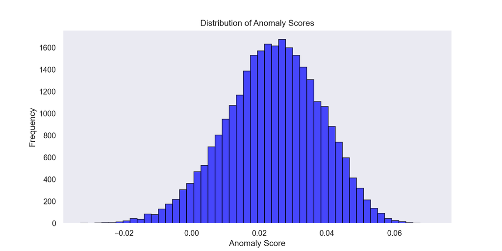

```python
plt.figure(figsize=(10, 5))
plt.hist(processed_df_2['Anomaly_Score'], bins=50, alpha=0.7, color='blue', edgecolor='black')
plt.xlabel('Anomaly Score')
plt.ylabel('Frequency')
plt.title('Distribution of Anomaly Scores')

plt.show()
```

```python
plt.clf()
```

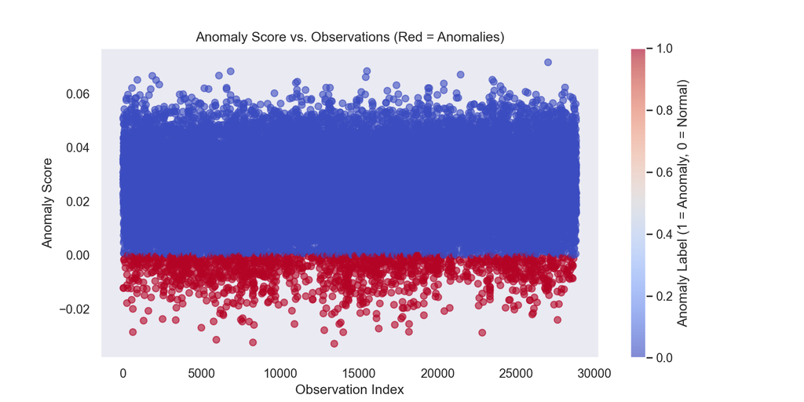

```python
plt.figure(figsize=(10, 5))
plt.scatter(processed_df_2.index, processed_df_2['Anomaly_Score'], c=processed_df_2['Anomaly_Label'], cmap='coolwarm', alpha=0.6)
plt.xlabel('Observation Index')
plt.ylabel('Anomaly Score')
plt.title('Anomaly Score vs. Observations (Red = Anomalies)')
plt.colorbar(label="Anomaly Label (1 = Anomaly, 0 = Normal)")
plt.show()
```